# Processando a Informação: Cap. 1: Fundamentos

[figure not shown]

Este caderno (*Notebook*) é uma parte complementar *online* do livro **[Processando a Informação](https://editora.ufabc.edu.br/matematica-e-ciencias-da-computacao/58-processando-a-informacao): um livro prático de programação independente de linguagem**, que deve ser consultado em caso de dúvidas sobre os temas apresentados.

> Este conteúdo pode ser copiado e alterado livremente, sendo inspirado por este livro.

**Bem-vindo ao Google Colab!**

Se você é novo no uso do Colab, assista aos vários [vídeos em português](https://www.youtube.com/results?search_query=introdu%C3%A7%C3%A3o+ao+colab) que explicam a plataforma. Existem também **workbooks** introdutórios para o uso do Python e do Colab na [página principal](https://colab.research.google.com/) do projeto.

De forma muito resumida, o Colab combina **células de texto e de código**. Esse paradigma de unir documentação e código em um único documento foi introduzido por Donald Knuth em 1984 [[ref1](https://www-cs-faculty.stanford.edu/~knuth/), [ref2](http://www.literateprogramming.com)].

## Instruções

- Recomenda-se fazer uma cópia deste *notebook* clicando em **"Arquivo"** --> **"Salvar cópia no drive"**. Dessa forma, você poderá editá-lo e executar os campos de código sempre que desejar, sem perder o seu progresso ao fechar esta página. Essa cópia estará disponível na pasta **Colab Notebooks** no seu Google Drive.
- Para editar uma **CÉLULA DE TEXTO** (como esta), basta dar dois cliques na célula e editar. As alterações podem ser visualizadas na aba à direita (ou abaixo), ou pressionando "*Shift+Enter*", ou clicando em outra célula.
- No Colab, há também a **CÉLULA DE CÓDIGO**, que pode ser executada com esta combinação de teclas, ou clicando no botão **"executar"** ou **"play"** para ver a saída do código inserido.
- Recomenda-se seguir a ordem sugerida dos exercícios, uma vez que a familiaridade com os conceitos introduzidos é esperada nos exercícios seguintes.
- É possível executar códigos independentes em IDEs e também *online*, usando navegadores como o Chrome: [PythonTutor](https://pythontutor.com), [Ideone](https://ideone.com/), [CodeChef IDE](https://www.codechef.com/ide), [Replit](https://replit.com/), [JDoodle](https://www.jdoodle.com).
- Também é possível executar códigos em seu celular, acessando esses links em navegadores.
- Este arquivo *Notebook* com extensão `.ipynb` pode ser editado no Jupyter Notebook, disponível em https://jupyter.org.

## Sumário

- Introdução à arquitetura de computadores: Hardware e Software
- Algoritmos, fluxogramas e lógica de programação
- Conceitos de linguagens de programação
- Variáveis, tipos de dados e organização da memória
- Operadores e precedência
- Aprendendo a programar
- Revisão deste capítulo
- Exercícios

## Introdução à Arquitetura de Computadores

A arquitetura (ou organização dos principais componentes) mais conhecida de computadores foi introduzida por John von Neumann, em 1936, conforme ilustrado na Figura abaixo.

[figure not shown]

[figure not shown]

- Um software é um conjunto de linhas de código armazenado em arquivo na memória secundária ou na RAM, que pode ser executado, instrução por instrução, na CPU.
- Essas linhas de código são instruções que o computador pode executar, mas que podem ter sido traduzidas de um **algoritmo**.

## Algoritmos, Fluxogramas e Lógica de Programação

```
ALGORITMO (algumas definições):
1. Um processo ou conjunto de regras a serem seguidas no cálculo ou em outra operação de resolução de problemas, especialmente por um computador.
2. Um processo de resolução de um problema composto por uma sequência ordenada e bem definida de passos que, em um tempo finito, levam à solução do problema ou indicam que, para o mesmo, não existem soluções.
```

Um exemplo de algoritmo para a solução de uma equação do segundo grau no formato $ax^2 + bx + c$, dados $a$, $b$ e $c:

1. Calcule $\Delta$ com a fórmula $\Delta = b^2 - 4ac$;
2. Se $\Delta < 0$, então $x$ não possui raízes reais;
3. Se $\Delta = 0$, então $x$ possui duas raízes reais idênticas;
4. Se $\Delta > 0$, então $x$ possui duas raízes reais e distintas;
5. Calcule as raízes reais.

### Pseudocódigo

- A sequência de passos definidos no algoritmo anterior, quando incluídas as instruções `leia(algo)` e `escreva(algo)`, pode ser definida como um **pseudocódigo**.
- Esse **pseudocódigo** é utilizado para que os humanos possam entender os passos de um algoritmo de uma forma "mais próxima" da maneira como os computadores processam as instruções, por meio de uma linguagem de programação, que será definida na próxima seção.

```
leia(a, b, c)
delta = b**2 - 4*a*c

se delta < 0:
    escreva("x não possui raízes reais")
    fim do programa
se delta == 0:
    escreva("x possui duas raízes reais idênticas")
se delta > 0:
    escreva("x possui duas raízes reais e distintas")

raiz1 = (-b + delta**0.5) / (2*a)
raiz2 = (-b - delta**0.5) / (2*a)

escreva(raiz1, raiz2)
```

É importante observar que o pseudocódigo fornece uma descrição mais detalhada das instruções em comparação com um algoritmo, embora não seja tão formal quanto as linguagens de programação.

### Fluxogramas

- Os algoritmos, além de poderem ser representados por listas de instruções, como no último exemplo, podem ser representados graficamente para facilitar a compreensão.
- Os fluxogramas e os diagramas de atividades da UML (*Unified Modeling Language*) estão entre as representações mais utilizadas.
- Ambos, que são bastante semelhantes, empregam formas e setas para indicar operações e seus fluxos.
- A figura abaixo ilustra um exemplo de fluxograma.

[figure not shown]

[figure not shown]

Esse fluxograma foi gerado automaticamente ao executar as duas células de código abaixo.

**Observação:** Apesar de o livro-texto ser independente de linguagem, alguns códigos nesta adaptação no Colab serão apresentados na linguagem de programação Python, devido à facilidade didática na apresentação de conteúdos. Portanto, os detalhes desses códigos não serão abordados, uma vez que estão fora do escopo.

```python
# instalando algumas bibliotecas no servidor do Colab (Linux)
!apt-get install graphviz libgraphviz-dev pkg-config
!pip install txtoflow
```

```python
# Importando a biblioteca txtoflow para gerar um fluxograma a partir de código
from txtoflow import txtoflow

# Definindo o pseudocódigo e passando-o como entrada para gerar o fluxograma
txtoflow.generate(
  '''
  Início;
  Abrir forno;
  if (forno aceso?) {
    Colocar lenha;
  } else {
    Acender fogo;
  }
  Assar pão;
  Fim;
  '''
)
```

- Após executar a célula de código acima, você pode visualizar o arquivo `flowchart.jpg` clicando no ícone da pasta à esquerda.

[figure not shown]

- Veja outro fluxograma gerado a partir da célula abaixo;

  > Embora o primeiro fluxograma seja intuitivo, os detalhes (principalmente do próximo fluxograma) serão abordados durante este curso!

```python
# definindo uma variável do tipo texto (string) para armazenar o pseudocódigo
alg2 = '''
leia(A);
B = 10;
if ( A > 0 ) {
  escreva("'A' Positivo");
} else if ( A >- 10 ) {
  escreva("'A' Negativo: -10<A<=0");
  B = A;
  while ( B < 0 ) {
    B = B + 1;
  }
}
escreva("B=",B);
Fim;'''

# Criando o fluxograma
txtoflow.generate(alg2)
```

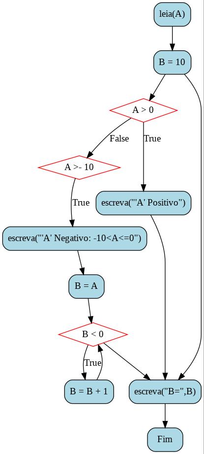

- Qual é o valor final de B neste algoritmo, se o valor lido foi `A=-5`?
- Experimente também esta ferramenta online: [code2flow](https://app.code2flow.com/).

#### Fluxograma a partir de código python

A sequência de códigos a seguir gera fluxogramas na própria célula de código, ao contrário de salvar em um arquivo de imagem. Além disso, a entrada é um código em Python, ao contrário do exemplo anterior que estava em pseudocódigo.

```python
# instalações necessárias
!pip install --upgrade git+https://github.com/innovationOUtside/flowchart_js_jp_proxy_widget.git
```

```python
from google.colab import output
output.enable_custom_widget_manager()
```

```python
alg3 = '''
A = int(input())
B = 10
if A > 0:
  print("'A' Positivo")
elif A > -10:
  print("'A' Negativo: -10<A<=0")
  B = A
  while B < 0:
    B = B + 1
    print(B)
print("B=",B)'''
```

```python
from pyflowchart import Flowchart
fc = Flowchart.from_code(alg3)
flowchart = fc.flowchart()
```

```python
from jp_flowchartjs.jp_flowchartjs import FlowchartWidget

testEmbed = FlowchartWidget()
testEmbed.charter(flowchart)
testEmbed
```

## Conceitos de Linguagens de Programação

Linguagem é um conjunto de regras usado para definir uma forma de comunicação. Esses são conceitos fundamentais em qualquer linguagem, não apenas na computação:

- **Sintaxe:** o arranjo de palavras e sua disposição em um discurso para criar frases bem formadas e relacionadas de forma lógica em uma linguagem;
- **Semântica:** o ramo da linguística preocupado com a lógica e o significado das palavras. Sub-ramos incluem a semântica formal e a semântica lexical.

### Níveis de Liguagens

O nível de linguagem diz respeito à proximidade com a linguagem natural humana.

[figure not shown]

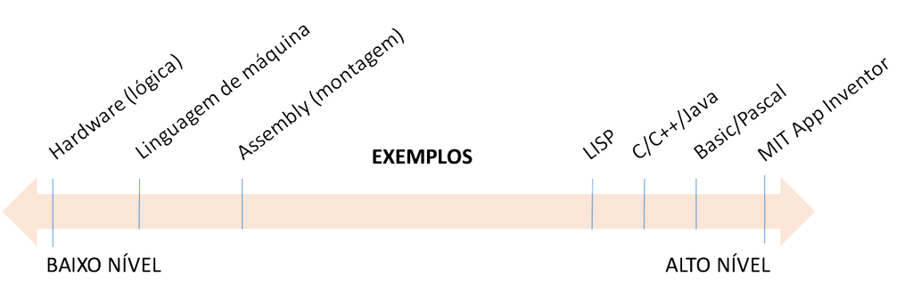

### Linguagem Compilada vs Interpretada

- **Compilação** é o processo de traduzir um código escrito em uma linguagem de alto nível para código de máquina, que pode ser executado na arquitetura apropriada para a qual foi compilado.
  - Exemplos de linguagens compiladas incluem: C, C++, Pascal e Fortran.
- Em **Linguagens Interpretadas**, os comandos do programa são transformados em código nativo durante a sua execução, geralmente por outro programa necessário para seu funcionamento.
  - Exemplos de linguagens interpretadas são: Python (neste Colab), R e MATLAB.
- A exceção é a linguagem **Java**, que compila um código binário em bytes (**bytecode**) para ser executado não em uma arquitetura real específica, mas sim pela **Máquina Virtual Java** (JVM), que é um **programa nativo** (ou seja, é necessário um JVM compilado para cada arquitetura). A JVM é responsável por transformar o bytecode na linguagem de máquina nativa do processador em tempo de execução (**runtime**).
- A existência de JVM para a maioria das plataformas aumentou significativamente a portabilidade dos programas. A **portabilidade** foi uma das principais motivações para a criação da linguagem Java.

### Estruturas de Código

Independentemente da linguagem escolhida, as estruturas fundamentais de código que estarão presentes em todas elas são:

1. **Código sequencial:** os comandos são executados na ordem em que aparecem.
2. **Módulos de código (funções ou métodos):** conjuntos de comandos agrupados em sub-rotinas ou subprogramas.
3. **Desvios condicionais:** dada uma condição, existem dois caminhos possíveis (duas linhas) de execução.
4. **Estruturas de repetição ou laços:** conjuntos de comandos que se repetem enquanto uma dada condição for satisfeita.

### Deburação de Código (DEBUG)

- O processo árduo de busca e correção de erros de programação no código escrito em linguagens de programação é conhecido como depuração ou "debugging".
- Ferramentas de depuração são de grande utilidade para ajudar na busca e correção desses erros.
- Alguns dos erros comuns encontrados no código, classificados do menos grave ao mais sério, incluem:
> 1. **Erro de semântica:** envolve palavras reservadas ou operações escritas de forma incorreta.
> 2. **Erro de sintaxe:** ocorre devido ao uso inapropriado do formato dos comandos.
> 3. **Erro de organização:** envolve blocos de código, aspas ou o uso de parênteses inconsistentes, ocorrendo quando se abre um bloco de código ou operadores (usando chaves, colchetes ou parênteses) ou um campo de texto (usando aspas) sem fechá-los ou fechar sem abrir.
> 4. **Erro de lógica:** também conhecido como "Cerberus" (o cão de guarda do inferno), ocorre quando os comandos estão sintaticamente corretos, têm a semântica correta e são escritos de forma consistente, mas estão em uma ordem, forma ou disposição que produz um resultado diferente do desejado. Esse resultado frequentemente causa o travamento da execução do programa ou até mesmo do computador.

### Ambientes de Desenvolvimento Integrados

Ambientes de Desenvolvimento Integrado, conhecidos como IDE (*Integrated Development Environment*), oferecem uma combinação de ferramentas úteis para escrever, executar e depurar o código de programas.

Algumas ferramentas populares do tipo IDE incluem:

- **Eclipse** (C, C++, Java, PHP, Android, etc).
- **NetBeans** (C, C++, Java, Ruby, HTML5, PHP, etc).
- **PyCharm** (Python, JavaScript, CoffeeScript, XML, HTML/XHTML).
- **Xcode** (IDE de desenvolvimento para dispositivos Apple).
- **Visual Studio** (C, C++, C#, Visual Basic, entre outros, voltado para o desenvolvimento de programas na plataforma Windows).
- **[VSCode](https://vscode.dev)** (versão *online* de código aberto do Visual Studio).
  - Para executar/debugar nesta versão *online*, é necessário ter uma conta no GitHub.
  - Para download e uso local, acesse: https://code.visualstudio.com/download.

Segue uma lista de *links* úteis para programar em várias linguagens *online*:

**Linguagens Gerais:**

- [Google Colab](https://colab.research.google.com)
- [Replit](https://replit.com/languages)
- [DrJava](http://www.drjava.org)
- [NBPortable](https://sourceforge.net/projects/nbportable)
- [Ideone](https://ideone.com)
- [CodeChef IDE](https://www.codechef.com/ide)

**Python:**

- [Programiz Python Online Compiler](https://www.programiz.com/python-programming/online-compiler/)
- [OnlineGDB Python Compiler](https://www.onlinegdb.com/online_python_compiler)
- [Tutorialspoint Python Compiler](https://www.tutorialspoint.com/execute_python_online.php)
- [Python.org Shell](https://www.python.org/shell/)
- [PythonTutor](http://pythontutor.com)

**Para Baixar IDEs:**

- [Anaconda Distribution](https://www.anaconda.com/distribution)
- [NetBeans](https://netbeans.org)

**Links Interessantes:**

- [Learn X in Y Minutes - Python](https://learnxinyminutes.com/docs/python3)
- [Learn X in Y Minutes - Java](https://learnxinyminutes.com/docs/java)
- [Learn X in Y Minutes - C](https://learnxinyminutes.com/docs/c)
- [YouTube - Como Programar](https://youtu.be/UNSoPa-XQN0)

Se você conhece outros *links* interessantes que não estão nestas listas, compartilhe!

#### Algumas Estatísticas sobre as Linguagens Mais Usadas:

- [Tendências de Linguagens no Stack Overflow](https://insights.stackoverflow.com/trends?tags=python%2Cjava%2Cjavascript)
  - [Reportagem sobre o Crescimento da Linguagem Python](https://profdanielbrandao.wordpress.com/2019/03/01/o-incrivel-crescimento-da-linguagem-python/)
- [Pesquisa Stack Overflow 2020](https://insights.stackoverflow.com/survey/2020)
- [Tecnologias Mais Populares na Pesquisa Stack Overflow 2020](https://insights.stackoverflow.com/survey/2020#most-popular-technologies)
- [As Principais Linguagens de Programação de 2023 (IEEE Spectrum)](https://spectrum.ieee.org/the-top-programming-languages-2023)

## Variáveis

- Uma variável na programação de computadores é um indicador ou "apelido" (*alias*) atribuído a um endereço de memória que contém um dado armazenado.
- Os elementos na memória, representados por variáveis, podem conter apenas um ou múltiplos valores e são codificados na memória de acordo com o tipo específico do dado, com um formato e número apropriado de bits para mantê-los.

### Uso de Variáveis

Em qualquer linguagem de programação, um valor pode ser atribuído a uma variável por meio do operador de atribuição, por exemplo: '='.

#### Exemplos de variáveis do tipo inteiro:

- As próximas células de código em Python podem ser executadas clicando em `[ ]` ou na seta de reprodução (*play*), localizada na margem esquerda.
- Se o seu objetivo é aprender outras linguagens de programação, essas células em Python podem ser usadas para fins comparativos.

```python
idade = 20        # Este é um comentário
anoAtual = 2024;  # Observe que ';' é opcional em Python e JavaScript
```

A leitura correta para o código representado acima é **"a variável `idade` recebe o valor 20"**.

```python
idade
```

```python
anoNascimento = anoAtual - idade
anoNascimento
```

#### Exemplo de variável do tipo texto (*string*)

```python
nomeAluno = 'Rafael Morais'
nomeAluno
```

Observe que o texto deve ficar entre aspas simples ou duplas (dependendo das linguagem escolhida).

#### Exemplo de variável do tipo real

```python
pi = 3.1415926535897932
pi
```

Observe que tem que usar '.' para separar as casas decimais.

#### Nomenclatura

- Os nomes das variáveis podem conter letras, números e alguns caracteres especiais, desde que não sejam reservados pela linguagem (como os símbolos de operadores matemáticos, lógicos e relacionais, por exemplo).
- Geralmente, o nome de uma variável deve começar com uma letra ou, dependendo da linguagem, algum caractere especial.
- Como regra geral, os nomes das variáveis não devem começar com números nem conter espaços.

Exemplos de variáveis válidas e inválidas:

| Válido | Inválido |  |
| --- | --- | --- |
| idade4 | 4idade |  |
| Nome_Completo | Nome Completo |  |
| resta_um | resta-um |  |
| V8S9F0D7S7D9 | V@R!V&+ | A-B=D |

## Operadores e precedência

As linguagens reservam alguns caracteres para uso em operadores ou indicadores de tipo.

### Operadores aritmeticos

Tabela: Operadores aritméticos em Java/C/CPP/JS

| operador | descrição |
| --- | --- |
| + | soma com |
| - | subtração por |
| * | multiplicação por |
| / | divisão por |
| % | resto da divisão por |
| ++ | incremento |
| -- | decremento |

### Operadores relacionais e de conjunto

Tabela: Operadores relacionais em Java/C/CPP/JS

| operador | descrição |
| --- | --- |
| == | é igual a |
| != | é diferente de |
| > | é maior que |
| < | é menor que |
| >= | é maior ou igual a |
| <= | é menor ou igual a |

### Operadores lógicos

Tabela: Operadores lógicos binários em Java/C/CPP/JS

| operador | descrição |
| --- | --- |
| x **&&** y | True se ambos também forem |
| x **&** y | True se ambos também forem bit-a-bit |
| x **\|\|** y | False se ambos também forem |
| x **\|** y | False se ambos também forem bit-a-bit |
| **!** x | contrário de x |
| **~** x | contrário de x bit-a-bit |
| **^** x | ou exclusivo `XOR` bit-a-bit |
| **<<**N | *shift-left*, adiciona N zeros à direita do número binário |
| **<<**N | *shift-right*, elimina N zeros à direita do número binário |

### Operadores de atribuição

Tabela: Operadores de atribuição em Python/Java/C/CPP/JS

| operador | descrição |  |
| --- | --- | --- |
| = | recebe o valor de |  |
| += | é somado ao valor de |  |
| -= | é subtraído do valor de |  |
| *= | é multiplicado pelo valor de |  |
| /= | é dividido pelo valor de |  |
| %= | recebe o resto da divisão por |  |
| similarmente | >>=, <<=, &=, | =, ^= |

### Precedência de Operadores

Quando utilizados em uma expressão, os operadores apresentados anteriormente são executados em ordem de precedência, de forma semelhante ao que fazemos em equações matemáticas, com adições, subtrações, multiplicações, divisões, exponenciais, etc. (teste a tabela abaixo na linguagem escolhida).

Tabela: Precedência de Operadores

| Categoria | Operador | Associatividade |
| --- | --- | --- |
| Pós-fixado | () (parênteses, operador ponto) | $\rightarrow$ Esquerda para a direita |
| Índice | [] | $\rightarrow$ Esquerda para a direita |
| Unário | ++ - - ! ~ (incremento, decremento) | $\leftarrow$ Direita para a esquerda |
| Multiplicativo | * / % (vezes, dividido, resto) | $\rightarrow$ Esquerda para a direita |
| Aditivo | + - (soma, subtração) | $\rightarrow$ Esquerda para a direita |
| Shift binário | >> >>> << | $\rightarrow$ Esquerda para a direita |
| Relacional | > >= < <= | $\rightarrow$ Esquerda para a direita |
| Igualdade | == != (é igual a, é diferente de) | $\rightarrow$ Esquerda para a direita |
| E (AND) bit-a-bit | & | $\rightarrow$ Esquerda para a direita |
| XOR bit-a-bit | ^ | $\rightarrow$ Esquerda para a direita |
| Ou (OR) bit-a-bit | \| | $\rightarrow$ Esquerda para a direita |
| E lógico | && | $\rightarrow$ Esquerda para a direita |
| Ou lógico | \|\| | $\rightarrow$ Esquerda para a direita |
| Condicional | ?: | $\leftarrow$ Direita para a esquerda |
| Atribuição | = += -= *= /= %= >>= <<= &= ^= \|= | $\leftarrow$ Direita para a esquerda |

#### Tipos básicos de variáveis

#### Conversões de tipos de variáveis

Tabela: Tipos de variáveis em Java/C/CPP/JS

| **Tipo** | **Descrição** | **n. Bits** | **Mínimo** | **Máximo ( valor )** |
| --- | --- | --- | --- | --- |
| **Tipos inteiros+sinal** |  |  |  |  |
| byte | inteiro de 1 byte | $8$ | $-128$ | $127$ |
| short | inteiro curto | $16$ | $-2^{15}$ | $2^{15}-1$ |
| int | inteiro | $32$ | $-2^{31}$ | $2^{31}-1$ |
| long | inteiro longo | $64$ | $-2^{63}$ | $2^{63}-1$ |
| **Tipos reais+ponto flut.** |  |  |  |  |
| float | precisão simples | $32$ | $2^{-149}$ | $(2-2^{-23})2^{127}$ |
| double | precisão dupla | $64$ | $2^{-1074}$ | $(2-2^{-52}))2^{1023}$ |
| **Tipos lógicos** |  |  |  |  |
| boolean | valor booleano | $1$ | $false$ | $true$ |
| **Tipos alfanuméricos** |  |  |  |  |
| char | caractere unicode | $16$ | $0$ | $2^{16}-1$ |
| **Classecadeia de caract.** |  |  |  |  |
| String | sequência n chars | $16*n$ | - | - |
| **Outras** |  |  |  |  |
| void | variável vazia | $0$ | - | - |

Tabela: Exemplos de conversão de valores entre tipos de variáveis

| **Conversão** | **Método** | **Exemplo** |
| --- | --- | --- |
|  |  | **C/C++/Java** |
| float $\rightarrow$ int | Type cast | `int i = (int) varFloat;` |
| double $\rightarrow$ float | Type cast | `float f = (float) varDouble;` |
| float, int $\rightarrow$ double | Direto | `double d = i; d = f;` |
| Número $\rightarrow$ String | (Java) direto (C) stdlib.h | `String str = "" + f; str = snprintf(num);` |
| String $\rightarrow$ int | (Java) parse (C) stdlib.h | `i = Integer.parseInt(str); i = atoi(str);` |
| String $\rightarrow$ float | (Java) parse (C) stdlib.h | `f = Float.parseFloat(str);f = atof(str);` |
| String $\rightarrow$ double | (Java) parse (C) stdlib.h | `d = Double.parseDouble(str);d = strtod(str, NULL);` |
|  |  | **JavaScript** |
| String $\rightarrow$ int | Parse | `var i = parseInt(str);` |
| String $\rightarrow$ float | Parse | `var f = parseFloat(str);` |
| Número $\rightarrow$ String | toString() | `var str = toString(f);` |

## Teste de mesa

- Teste de mesa é o nome dado à simulação manual da execução de um programa, acompanhando o estado das variáveis e a mudança temporal de seus valores, seja feito no papel ou mentalmente.
- Geralmente, anotam-se os nomes das variáveis à medida que aparecem, juntamente com seus respectivos valores. Quando as variáveis são modificadas, os novos valores substituem os anteriores, que são atualizados (riscados) na tabela a cada nova instrução que as modifica.
- Os valores finais das variáveis, ao término do programa, são os últimos valores assumidos por cada uma delas.

| código | c | f | ano | idd |
| --- | --- | --- | --- | --- |
| `c = 1` | 1 |  |  |  |
| `f = 22` |  | 22 |  |  |
| `ano = 1994` |  |  | 1994 |  |
| `idd = 0` |  |  |  | 0 |
| `ano=ano+idd` |  |  | 1994 |  |
| `idd *= f` |  |  |  | 0 |
| `c += 1` | 2 |  |  |  |
| `ano+=f` |  |  | 2016 |  |
| `f -= 4` |  | 18 |  |  |
| `c += 1` | 3 |  |  |  |

## Aprendendo a programar

- Uma sugestão prática para experimentar algumas linguagens de programação é começar escrevendo um programa bem simples.
- Escreva um programa para imprimir a mensagem:

`Alô, Mundo!`

##### Salvando um arquivo

Para salvar um arquivo contendo os códigos de uma célula de código, basta inserir na primeira linha o comando `%%writefile nomeArquivo.ext`.

###### Exemplo 01 - Escreva 'Alô Mundo!'

###### Casos para Teste no Moodle+VPL

Para o professor criar uma atividade VPL no Moodle para este Exemplo 01, basta incluir o seguinte texto em "Casos para teste":

```
case=caso1
output=Alô, Mundo!
```

- Portanto, quando o estudante submeter um código em uma atividade VPL no Moodle, o servidor de correções irá comparar as entradas e saídas apenas!
- Em outras palavras, o código submetido pelo estudante deve **ler as entradas (se existirem) e gerar a saída esperada, independentemente da linguagem de programação**.

```python
%%writefile cap1ex01.java
class cap1ex01 {
	public static void main (String[] args) {
    System.out.println("Alô, Mundo!");
	}
}
```

```python
%%writefile cap1ex01.html
<!DOCTYPE html>
<html>
  <head>
    <meta charset="utf-8">
    <title>UFABC</title>
    <script>
      // código em javascript
      var ola = 'Alô, Mundo!'
    </script>
  </head>
  <body>
    <script>
      document.write(ola)
    </script>
  </body>
</html>
```

Teste os códigos antes de submetê-los para avaliação no Moodle+VPL, por exemplo, em https://www.jdoodle.com/execute-nodejs-online.

```python
%%writefile cap1ex01.c
#include <stdio.h>
int main(void) {
  printf("Alô, Mundo!");
  return 0;
}
```

```python
!gcc -Wall -std=c99 cap1ex01.c -o output2
!./output2
```

- O comando `%%writefile` salva o arquivo no servidor *colab* (pasta à esquerda).
- O comando após `!` roda no terminal.
- `gcc` é o compilador utilizado, com os argumentos:
  - `-Wall` para mostrar *warnings* (programas mal feitos)
  - `-std=c99` compilador padrão ANSI (`c99` é um padrão de 1999, porém existem outros, ver por exemplo ref1 e [ref2](https://pt.wikipedia.org/wiki/Biblioteca_padr%C3%A3o_do_C)), compatível em mais arquiteturas
  - arquivo de entrada `cap1ex01.c`
  - `-o` arquivo de saída executável

É possível copiar e colar o código acima (excluindo a primeira linha iniciada com `%%writefile arquivo.ext`) e executá-lo localmente no Terminal (*Shell* ou *Console*), em IDEs ou *online*. Experimente!

Após executar a célula de código acima, você pode visualizar o arquivo clicando no ícone da pasta à esquerda.

Clique no arquivo e, em seguida, nos três pontos, para fazer o *download* para o seu computador. Você pode editar e executar esses arquivos em IDEs instaladas em seu computador ou em aplicativos no seu celular, ou também *online*.

O Colab suporta a linguagem Python nativa nas células de código.

Para executar as células com código java no colab, uma solução é:

1. instalar `!apt-get install default-jre`
2. salvar uma célula com código java em um arquivo incluido na primeira linha `%%writefile nomeArquivo.java`
3. compilar com `!javac nomeArquivo.java`
4. executar com `!java nomeArquivo`

> **ATENÇÃO:** o nome da classe TEM QUE SER O **NECESSARIAMENTE** o nome do arquivo, sem a expensão. Por exemplo, para o arquivo `cap1ex01.java`, o nome da classe tem que ser `cap1ex01`, como está na linha `class cap1ex01 {`.

```python
!apt-get install default-jre
```

```python
!javac cap1ex01.java
!java cap1ex01
```

Observe no código `cap1ex01.html` que o código em javascript fica entre as *tags* `<script>` e `<\script>`. O javascript foi criado para trabalhar junto com documentos em HTML. Porém, é possível executar separademente, como no exemplo a seguir:

```python
%%javascript
element.append("Alô, Mundo!");
```

```python
%%writefile cap1ex01.js
console.log("Alô, Mundo!")
```

```python
!node cap1ex01.js
```

Ou ainda, como abaixo, dentro deste notebook.

> Mas lembre-se, a melhor forma de usar um código javascript é fazendo parte de um documento HTML e executar dentro de um navegador, com Chrome, Firefox, Edge, etc.

```python
%%html
<!DOCTYPE html>
<html>
  <head>
    <meta charset="utf-8">
    <title>UFABC</title>
    <script>
      var message = "Alô, Mundo!"
    </script>
  </head>
  <body>
    <h1>Primeiro programa</h1>
    <script>
      document.querySelector("#output-area").appendChild(document.createTextNode(message));
    </script>
  </body>
</html>
```

### Programação sequencial

A programação incorpora conceitos de matemática e lógica, incluindo variáveis e expressões algébricas. Assim como na matemática, a seguinte expressão resultará em `C = 10`.

```
int A = 2, B = 3;
int C = (A+B) * 2;
```

### Entrada de dados

###### Exemplo(s) 02 - Entrada de Dados

###### Casos para Teste Moodle+VPL

Para o professor criar uma atividade VPL no Moodle para este Exemplo 02, basta incluir o seguinte texto em "Casos para teste", com 4 casos (você pode incluir mais casos):

```
case=caso1
input=65
output=
65 graus Celsius corresponde a 149.0 graus Fahrenheit
case=caso2
input=55
output=
55 graus Celsius corresponde a 131.0 graus Fahrenheit
case=caso3
input=45
output=
45 graus Celsius corresponde a 113.0 graus Fahrenheit
case=caso4
input=35
output=
35 graus Celsius corresponde a 95.0 graus Fahrenheit
```

A entrada de dados em Java ocorre com um sequência de comandos, veja exemplo a seguir:

```python
%%writefile cap1ex02.java
import java.util.Scanner;
class cap1ex02 {
	public static void main (String[] args) {
    Scanner teclado1 = new Scanner(System.in);
    int C = teclado1.nextInt();
    float F = C * 9/5 + 32;
    System.out.println(C+" graus Celsius corresponde a "+F+" graus Fahrenheit");
	}
}
```

```python
!javac cap1ex02.java
!java cap1ex02
```

[figure not shown]

Existem outras formas de executar Java no Colab, mas não serão utilizadas nesta oferta de PI. Como um exemplo:

1. O arquivo *.ipynb tem que estar como java (abrir com um editor de texto) e mudar:

`{"name":"python3","display_name":"Python 3"}` para `{"name":"java","display_name":"java"}` 2. Fazer upload do arquivo *.ipynb alterado 3. Copiar o código abaixo, colar em uma célula de código e executar

```
!wget https://github.com/SpencerPark/IJava/releases/download/v1.3.0/ijava-1.3.0.zip
!unzip ijava-1.3.0.zip
!python install.py --sys-prefix
```

4. Recarregar a página e executar a próxima célula com código java. Ver [link](https://stackoverflow.com/questions/61832061/google-colab-with-java-using-jshell)

```
System.out.println("Olá, Mundo!");
```

A entrada de dados no javascript é bem complicada, pois espera-se uma comunicação com o HTML. Como no exemplos a seguir:

```python
%%html
<script>
  function calculate_this() {
  var input = document.getElementById('numbers').value;
  var results = eval(input);
  document.getElementById('results').innerHTML = results;
  }
</script>
Digite algo: <input type="text" id="numbers" value="2*2+1">
<input type=button value="Armazenar" onClick="calculate_this()"><br>
Result: <span id="results">(click "Armazenar")</span>
```

Para tentar contornar isso e fazer um código escrito em javascript puro executar online (por exemplo: https://www.jdoodle.com/execute-nodejs-online) e principalmente em atividades com correção automática no Moodle, utilizando o plugin VPL (Moodle+VPL), foi definido a seguinte sequência de código:

```python
%%html
<script>
    function calculate_this() {
    var C = parseInt(document.getElementById('number1').value);
    var F = C * 9/5 + 32
    var results = C + " graus Celsius corresponde a " + F.toFixed(1) + " graus Fahrenheit"
    document.getElementById('results').innerHTML = results;
    }
</script>
Digite algo: <input type="text" id="number1" value="55">
<input type=button value="calcular" onClick="calculate_this()"><br>
Result: <span id="results">(click "calcular")</span>
```

```python
%%writefile cap1ex02.js
var C = process.argv.slice(2)[0] // ATENÇÃO NESTA INSTRUÇÃO!
var F = C * 9/5 + 32
console.log(C + " graus Celsius corresponde a " + F.toFixed(1) + " graus Fahrenheit")
```

```python
!node cap1ex02.js 65 33
```

Essa seria uma solução para poder executar em uma atividade no Moodle+VPL:

```python
%%writefile cap1ex02.js
function escreva(s) {try {element.append(s)} catch(e) {try {document.write(s)} catch(e) {console.log(s)}}}
function ler(linhas,i) {return linhas.toString().split('\n')[i]}

process.stdin.once('data', linhas => {
    escreva("Entre com C: ")
    var C = ler(linhas,0) // ATENÇÃO NESTA INSTRUÇÃO!
    var F = C * 9/5 + 32
    escreva(C + " graus Celsius corresponde a " + F.toFixed(1) + " graus Fahrenheit")
})
```

```python
# NÃO RODA NESTE COLAB, SOMENTE NO MOODLE+VPL
%%shell
#node cap1ex02.js 65
```

> Se alguém tiver alguma sugestão para **fazer um mesmos código javascript executar neste notebook, online e no Moodle+VPL**, seria ótimo!

Para executar o console do `node` neste colab.

Digite `.exit` para finalizar a execução no `node` no `shell`.

```python
%%shell
node
```

```python
%%writefile cap1ex02.c
#include <stdio.h>
int main(void) {
  int C;
  scanf("%d", &C);
  float F = C * 9/5 + 32;
  printf("%d graus Celsius corresponde a %.1f graus Fahrenheit", C, F);
  return 0;
}
```

```python
%%shell
gcc -Wall -std=c99 cap1ex02.c -o output2
./output2
```

### Divisão de um código em três partes

- O uso eficaz de cada linguagem depende apenas da familiaridade do programador com a sintaxe, semântica e bibliotecas disponíveis, **o que só pode ser atingido com a prática**.
- Adicionalmente, para incorporar *inteligência* aos programas (ou boas práticas de programação), é necessário:
  - conhecimento de lógica de programação para saber como estruturar e
  - organizar os programas de forma a criar um fluxo contínuo de código:
    - partindo da **ENTRADA** (ou coleta) de dados,
    - seguido pelo **PROCESSAMENTO** da informação,
    - até a **SAÍDA** de dados, com a exibição dos resultados do processamento para o usuário.

> ENTRADA DE DADOS $\Rightarrow$ PROCESSAMENTO DA INFORMAÇÃO $\Rightarrow$ SAÍDA

As estruturas fundamentais de lógica de programação, usadas para orientar o fluxo do processamento, comuns a todas as linguagens de programação, serão apresentadas nos próximos três capítulos.

### Tipos de dados em C

O comando sizeof retorna a quantidade de bytes de cada variável.

```python
%%writefile cap1ex03.c
#include <stdio.h>
int main(void) {
  char ch;
  int i;
  long int li;
  short s;
  unsigned int ui;
  float f;
  double d;
  long double ld;

  printf("Numero de bytes por tipo de dados:\n");
  printf("char:         %ld\n", sizeof (ch));
  printf("int:          %ld\n", sizeof (i));
  printf("long int:     %ld\n", sizeof (li));
  printf("short:        %ld\n", sizeof (s));
  printf("unsigned int: %ld\n", sizeof (ui));
  printf("float:        %ld\n", sizeof (f));
  printf("double:       %ld\n", sizeof (d));
  printf("long double:  %ld\n", sizeof (ld));
  return 0;
}
```

```python
%%shell
gcc -Wall -std=c99 cap1ex03.c -std=c99 -Wall -o output3
./output3
```

### *Casts*

Para alterar um tipo de dados para outro, você pode usar *cast*.

```python
%%writefile cap1ex04.c
#include <stdio.h>
int main(void) {
  double d = 3.14;
  int i = (int)d; // AQUI ESTA O CAST
  printf("double = %f\n", d);
  printf("int = %d\n", i);
  return 0;
}
```

```python
%%shell
gcc -Wall -std=c99 cap1ex04.c -std=c99 -Wall -o output4
./output4
```

## Exercícios

Para visualizar o *notebook* Colab no arquivo `cap1.part2.lab.*.ipynb` (`X` $\in$ `[2,3,4,...]` e `*` é a extensão da linguagem), você pode utilizar a linguagem de programação de sua preferência e organizar os *notebooks* nas subpastas contidas na pasta **"gen"** dentro da pasta do Google Drive "colabs", acessível através deste [link](https://drive.google.com/drive/folders/1YlFwv8XYN7PYYf-HwDMlkxzbmXzJw9cM?usp=sharing).

## Revisão deste capítulo de Fundamentos

- Introdução à arquitetura de computadores; Hardware e Software
  - Destaque para a arquitetura de John Von Neumann.
- Algoritmos, fluxogramas e lógica de programação
  - Algoritmo define um conjunto de passos para o computador executar.
- Conceitos de linguagens de programação
  - Linguagens Compiladas vs Interpretadas.
- Variáveis, tipos de dados e organização da memória
  - Utilizar nomes sugestivos para as variáveis e definir corretamente o seu tipo.
- Operadores e precedência
  - Praticar a precedência de operadores em expressões matemáticas na linguagem escolhida.
- Aprendendo a programar
  - **Pratique! Só se aprende a programar se fizer todos os exercícios, sem copiar soluções prontas!**
- Exercícios

## Processando a Informação: Cap. 1: Fundamentos - Prática 1

[figure not shown]

Este caderno (*Notebook*) é uma parte complementar *online* do livro **[Processando a Informação](https://editora.ufabc.edu.br/matematica-e-ciencias-da-computacao/58-processando-a-informacao): um livro prático de programação independente de linguagem**, que deve ser consultado em caso de dúvidas sobre os temas apresentados.

> Este conteúdo pode ser copiado e alterado livremente, sendo inspirado por este livro.

### Instruções

- A lista de exercícios **PODERÁ NÃO SER AVALIADA PELO PROFESSOR**, mas entre em contato com o monitor ou o professor se tiver alguma dúvida.
- É recomendado **fazer uma cópia do notebook** clicando na opção **"copiar para o drive"** no menu acima à direita (você precisa estar logado na sua conta no Google para fazer isto). Alternativamente, selecione **"Arquivo"** → **"Salvar cópia no drive"**. Desta forma, você poderá editá-lo e executar os campos de código sempre que quiser, sem perder seu progresso ao fechar esta página.
- Após digitar o código pedido no campo indicado, clique no botão **"executar"** ou **"*play*"** para ver a saída do código inserido.
- É recomendado seguir a ordem sugerida dos exercícios, uma vez que a familiaridade com os conceitos introduzidos é esperada nos exercícios seguintes.
- O *notebook Colab* tem o Python nativo para executar as células de código. Se desejar outra linguagem de programação, consulte o material do **Capítulo 1**, na pasta do Google Drive [colabs](https://drive.google.com/drive/folders/1YlFwv8XYN7PYYf-HwDMlkxzbmXzJw9cM?usp=sharing).

### Sugestões para envio dos exercícios com avaliação automática no Moodle+VPL

- Fique atento as datas de entrega no calendário do Moodle.
- Escolha uma linguagem de programação para submeter os exercícios (ou a definida pelo seu professor).
- A atividade no Moodle considera sempre a última submissão, com a nota atribuída de forma automática.
- Faça uma cópia do Colab e tente resolver as questões aqui, ou em alguma IDE de sua preferência, antes de enviar para avaliação no Moodle.
- É possível executar códigos independentes em IDEs e também *online*, utilizando navegadores como o chrome: https://pythontutor.com/, https://ideone.com/, https://www.codechef.com/ide, https://replit.com/, https://www.jdoodle.com.
- É possível também executar códigos no seu celular, utilizando navegadores acessando esses *links*.

### Exercícios

1. No espaço abaixo, escreva um programa para exibir a mensagem "Alô mundo!". Execute-o e verifique se a saída está correta.
2. **Complete** o processamento do código abaixo com a fórmula correta para o delta ($\Delta = b^2-4ac$) da equação do segundo grau, na forma $ax^{2}+bx+c=0$. **Dados**: a operação 'elevado' em Python é `**`. Considere alguns valores inteiros e reais para $a$, $b$ e $c$. **Resposta correta:** delta = 49

```
a = 2
b = 3
c = -5
```

3. **Complete o código anterior** no campo abaixo com comandos para calcular e exibir as raízes da equação do segundo grau, usando a fórmula $raiz_1=\frac{-b+\sqrt{\Delta}}{2a}$ e $raiz_2=\frac{-b-\sqrt{\Delta}}{2a}$. **Dados**: raiz de um número = número**.5 (elevado a meio). **Respostas:** (-2.5, 1.0).
4. Adicione `código` na parte indicada para trocar os valores das variáveis `a, b e c` (definidas anteriormente) de forma que `a` contenha o menor valor, `b` contenha o valor central e `c` contenha o maior valor. A última linha `(a, b, c)` não deve ser alterada. **Saída**: `(-5, 2, 3)`
5. Escreva abaixo um programa completo que leia dois números (devem ser digitados pelo usuário) e calcule e exiba a média. Quando executado, o programa deve gerar a seguinte saída:

```
Entre com o primeiro número: 10
Entre com o segundo número: 5
Média: 7.5
```

## Processando a Informação: Cap. 1: Fundamentos - Prática 2

[figure not shown]

Este caderno (*Notebook*) é uma parte complementar *online* do livro **[Processando a Informação](https://editora.ufabc.edu.br/matematica-e-ciencias-da-computacao/58-processando-a-informacao): um livro prático de programação independente de linguagem**, que deve ser consultado em caso de dúvidas sobre os temas apresentados.

> Este conteúdo pode ser copiado e alterado livremente, sendo inspirado por este livro.

### Exercícios

[Fonte: https://wiki.python.org.br/EstruturaSequencial]

1. Faça um programa que peça o raio ($R$) de um círculo, calcule e mostre sua área ($\pi R^2$) e seu perímetro ($2\pi R$).
2. Faça um programa que peça a Apótema ($a$, ver figura), o número ($n$) de lados do polígono regular e o comprimento $l$ de cada lado. Calcule e mostre a sua Área ($A=nla/2$). Essa fórmula funciona para triângulo equilátero e quadrado? [[fonte](https://www.todamateria.com.br/area-dos-poligonos/amp/)]

[figure not shown]

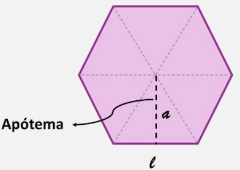

4. Faça um programa que peça a temperatura em graus Fahrenheit, transforme e mostre a temperatura em graus Celsius.
3. Faça um programa que pergunte quanto você ganha por hora e o número de horas trabalhadas por dia da semana (sem sábados e domingos). Calcule e mostre o total do seu salário semanal.
5. Faça um programa que solicite 2 números inteiros e um número real. Calcule e exiba:
- o produto do dobro do primeiro com metade do segundo;
- a soma do triplo do primeiro com o terceiro;
- o terceiro elevado ao cubo.
6. Tendo como dados de entrada a altura ($h$) de uma pessoa, construa um programa que calcule seu peso ideal, usando a seguinte fórmula:

$$72.7h - 58$$

7. Tendo como dado de entrada a altura ($h$) de uma pessoa, construa um programa que calcule seu peso ideal, utilizando as seguintes fórmulas:
- homens: $72.7h - 58$
- mulheres: $62.1h - 44.7$
8. João Papo-de-Pescador, homem de bem, comprou um microcomputador para controlar o rendimento diário de seu trabalho. Considere que ele sempre traz um peso de peixes maior que o estabelecido pelo regulamento de pesca do estado de São Paulo (50 quilos), neste caso, com uma multa de R$ 4,00 por quilo excedente. João precisa que você faça um programa que leia a variável peso (peso de peixes) e calcule o excesso. Grave na variável excesso a quantidade de quilos além do limite e na variável multa o valor da multa que João deverá pagar. Imprima os dados do programa com as mensagens adequadas.
9. Faça um programa que pergunte quanto você ganha por hora e o número de horas trabalhadas no mês. Calcule e mostre o total do seu salário no referido mês, sabendo-se que são descontados 11% para o Imposto de Renda, 8% para o INSS e 5% para o sindicato. Faça um programa que forneça as seguintes informações:
- Salário bruto.
- Quanto pagou ao INSS.
- Quanto pagou ao sindicato.
- Salário líquido.

O programa deve calcular os descontos e o salário líquido, conforme a tabela abaixo:

```
  + Salário Bruto : R$
  - IR (11%) : R$
  - INSS (8%) : R$
  - Sindicato  (5%) : R$
  = Salário Líquido : R$
```

Obs.: Salário Bruto - Descontos = Salário Líquido

10. Faça um programa para uma loja de tintas. O programa deve solicitar o tamanho em metros quadrados da área a ser pintada. Considere que a cobertura da tinta é de 1 litro para cada 3 metros quadrados e que a tinta é vendida em latas de 18 litros, custando R$ 80,00 cada. Informe ao usuário a quantidade de latas de tinta a serem compradas e o preço total.

## Processando a Informação: Cap. 1: Fundamentos - Prática 4: Tutorial VSCode

[figure not shown]

Este caderno (*Notebook*) é uma parte complementar *online* do livro **[Processando a Informação](https://editora.ufabc.edu.br/matematica-e-ciencias-da-computacao/58-processando-a-informacao): um livro prático de programação independente de linguagem**, que deve ser consultado em caso de dúvidas sobre os temas apresentados.

> Este conteúdo pode ser copiado e alterado livremente, sendo inspirado por este livro.

### Tuturial (em construção) VSCode

- **[VSCODE](https://vscode.dev)** - versão *online* de código aberto do *Visual studio*.
- Para download e uso local: https://code.visualstudio.com/download.
- Ver:
  - https://docs.microsoft.com/pt-br/learn/modules/introduction-to-github-visual-studio-code/
  - https://www.digitalocean.com/community/tutorials/how-to-use-git-integration-in-visual-studio-code-pt
  - https://balta.io/blog/git-github-primeiros-passos
- Clonar: https://github.com/fzampirolli/codigosPI, para PI
- Clonar: https://github.com/fzampirolli/codigosPE, para Programação Estruturada
  - Alterar `settings.json` em `code-runner.executorMap`:
    - `"c": "cd $dir && gcc -Wall -std=c99 $fileName -o ...`
      - `-Wall` para mostrar `warning` (programas ruins)
      - `-std=c99` - padrão ANSI ou C99, os programas seguindo esse padrão são mais portáveis, ou seja, possuem menos problemas de compatibilidade entre diferentes arquiteturas.

# Processando a Informação: Cap. 2: Organização de código

[figure not shown]

Este caderno (*Notebook*) é uma parte complementar *online* do livro **[Processando a Informação](https://editora.ufabc.edu.br/matematica-e-ciencias-da-computacao/58-processando-a-informacao): um livro prático de programação independente de linguagem**, que deve ser consultado em caso de dúvidas sobre os temas apresentados.

> Este conteúdo pode ser copiado e alterado livremente, sendo inspirado por este livro.

## Sumário

- Revisão do capítulo anterior
- Programas sequenciais
- Comentários
- Desvios de fluxo
- Programas e Subprogramas
- Funções, métodos e modularização
- Reaproveitamento e manutenção de código
- Revisão deste capítulo
- Exercícios

## Revisão do capítulo anterior (Fundamentos)

- No capítulo anterior, foram apresentados os fundamentos para começar a programar usando alguma linguagem de programação, além de alguns exemplos de códigos e, principalmente, de como executar esses códigos em ambientes de programação.
- Neste capítulo, iniciaremos a organização desses códigos, utilizando o conceito de sistema de informação em partes:
  - **ENTRADA DE DADOS $\Rightarrow$ PROCESSAMENTO DA INFORMAÇÃO $\Rightarrow$ SAÍDA**

## Programas sequenciais

- Como vimos no capítulo anterior, um programa consiste em uma **sequência lógica de comandos e operações** que, quando executados em ordem, realizam uma determinada tarefa.
- Em geral, um programa processa dados de entrada para obter o resultado desejado na saída.
- A **entrada** e a **saída** de dados são comumente realizadas usando dispositivos de entrada e saída, como teclado e monitor.
- Os dados necessários para o **processamento** também podem estar contidos no código do programa (no exemplo a seguir, poderiam ser `conta = 100`).
- No exemplo a seguir em **pseudocódigo**, a entrada é lida do teclado (comando `leia()`) e a saída é impressa no monitor (comando `escreva`).

```
# 1. ENTRADA de dados:
# 1.1 Definição das variáveis do programa:
conta: Real
gorjeta: Real

# 1.2 Entrada de dados
conta = leia("Entre com o valor da conta: ")

# 2. PROCESSAMENTO:
gorjeta = conta * 0.2

# 3. SAÍDA de dados (na tela):
escreva("Valor da gorjeta = " + gorjeta)
```

Assim, o procedimento para especificar um programa envolve:

1. Definir os dados de **entrada** necessários (insumos).
2. Especificar o **processamento** ou transformação dos dados de entrada em saída.
3. Determinar a **saída** desejada do programa.

## Comentários

- Comentários são trechos do código usados pelo desenvolvedor para incluir notas, explicações, exemplos, entre outros.
- Quando um comentário é definido, é dada uma instrução direta ao **compilador/interpretador para ignorar a parte comentada**.
- Isso significa que os comentários não são considerados durante a execução do código.
- Portanto, os comentários não fazem parte da execução.
- Cada linguagem de programação tem sua própria maneira de inserir comentários no código.

| Tabela. Identificadores de comentário. |  |  |
| --- | --- | --- |
| Linguagem | Uma linha | Várias linhas |
| Java/JS/C/C++ | //... | /*...*/ |
| Python | #... | """...""" ou '''...''' |
| Matlab | %... | %{...}% |
| Pascal | {...} | {*...*} |
| SQL | --... | /*...*/ |
| R | #.. |  |

## Desvio de Fluxo

- Um programa consiste em uma sequência de comandos executados em ordem, em uma linha contínua de execução.
- No entanto, essa linha de execução (em inglês: *thread*) pode conter desvios ou descontinuidades, processando códigos de bibliotecas ou subprogramas.

## Programas e Subprogramas

- Em grande parte das linguagens de programação, **os programas podem ser divididos em um ou mais arquivos ou partes**.
- Cada parte contém uma sequência de comandos com um objetivo específico, realizando uma tarefa dentro do programa.
- Dentro de um mesmo programa podem existir **subprogramas** (ou partes) com funções específicas ou subconjuntos de comandos que só serão executados em condições especiais.
- Todas as linguagens vêm acompanhadas de **bibliotecas**, que contêm funções ou programas de uso comum.
- São exemplos as funções para cálculos matemáticos, operações de entrada e saída, comunicação e conversão de dados.

## Bibliotecas

Cada linguagem de programação possui um conjunto de bibliotecas disponíveis para uso. As bibliotecas podem armazenar variáveis ou funções.

## Funções ou Métodos de Usuário

- O uso de funções facilita a **reutilização de código**, já que uma função é um programa autocontido, com **entrada**, **processamento** e **saída**.
- Uma função pode ser copiada de um programa para outro ou incorporada em uma biblioteca escrita pelo usuário, usando o comando `import myBiblioteca` em Python, ou `#include "myBiblioteca.h"` em C/C++/Java.
- Uma função é definida por um nome, um retorno (opcional), argumentos (opcionais) e um conjunto de instruções.

Abaixo, temos um exemplo de função de usuário escrita em pseudocódigo:

```
# MINHA(S) FUNÇÃO(ÕES)
função delta(recebe: real a, real b, real c) retorna real d {
     d = b^2 - 4ac
     retorne d
}

principal {
  # ENTRADAS
  a = 5
  b = -2
  c = 4

  # PROCESSAMENTO
  real valor = delta(a, b, c) # AQUI ESTÁ A CHAMADA DA FUNÇÃO

  # SAÍDA
  escreva("O delta de ax^2 + bx + c é " + valor)
}
```

```
TERMINOLOGIA: Os métodos podem ser chamados também de módulos,
funções, subprogramas ou procedimentos.

Existe uma convenção: quando um método tem argumento(s)
(parâmetros) e um retorno, é chamado de função; caso
contrário, é chamado de procedimento.

No entanto, poucas linguagens fazem distinção na sintaxe entre
função e procedimento, como a Pascal, tornando essa convenção
confusa.
```

#### Exemplo 01 - Uso de Funções

###### Casos para Teste Moodle+VPL

Para o professor criar uma atividade VPL no Moodle para este Exemplo 01, basta incluir em `Casos para teste`, o seguinte texto (pode incluir mais casos):

```
case=caso1
output=
O delta de ax^2 + bx + c é -76.0
```

[figure not shown]

```python
#https://drive.google.com/file/d/1x7uFa8lhaHUVG0mnCHc6PGbtTtMYrUn1/view?usp=drive_link
!pip install -U --no-cache-dir gdown --pre
!gdown --id 1x7uFa8lhaHUVG0mnCHc6PGbtTtMYrUn1
```

Observe que o **ESCOPO** da função é definido por `{` ... `}`:

```python
%%writefile cap2ex01.java
class cap2ex01 {
  public static void main(String[] args) {
    double a=5.0, b=-2.0, c=4.0;
    System.out.println("O delta de ax^2 + bx + c é " + delta(a, b, c));
  }
  public static double delta(double a, double b, double c){
    double d = b*b-4*a*c;
    return d;
  }
}
```

```python
!javac cap2ex01.java
!java cap2ex01
```

Observe que o **ESCOPO** da função é definido por `{` ... `}`:

```python
%%writefile cap2ex01.js
function delta(a, b, c){
    var d = b*b-4*a*c;
    return d;
  }

var a=5.0, b=-2.0, c=4.0;
console.log("O delta de ax^2 + bx + c é " + delta(a,b,c).toFixed(1))
```

```python
%%shell
node cap2ex01.js
```

Para rodar o console do `node` neste colab.

Digite `.exit` para finalizar a execução no `node` no `shell`.

```python
%%shell
node
```

Para rodar no Moodle+VPL, utilizar a seguinte sequência de código:

```python
%%writefile cap2ex01.js
function escreva(s) {try {element.append(s)} catch(e) {try {document.write(s)} catch(e) {console.log(s)}}}
function delta(a, b, c){
  var d = b*b-4*a*c;
  return d;
}

var a=5.0, b=-2.0, c=4.0;
escreva("O delta de ax^2 + bx + c é " + delta(a,b,c).toFixed(1))
})
```

```python
# NÃO RODA NESTE COLAB, SOMENTE NO MOODLE+VPL
%%shell
#node cap2ex02 3 4 2
```

Testar códigos antes de submeter para avaliação em Moodle+VPL, por exemplo, em https://www.jdoodle.com/execute-nodejs-online.

- Quando uma função não tem `return` ela deve retornar o tipo `void` (nada), por exemplo, `void escrevaDelta(float d){...}`.
- Os argumentos de uma função podem ser passados por **valor** ou por **referência**.
  - Por **valor**: qualquer alteração do argumento dentro da função não será passada para quem chamou a função.
  - Por **referência**: oposto ao anterior, qualquer alteração dentro da função será repassada para quem chamou e isso ocorre passando o endereço de memória da variável (com `&`) ao ser chamado. Por exemplo:

  - ```
    incrementaUm(&x)
    ```

  * Esse endereço de memória é definido como o tipo de dados **ponteiro** e será estudado em detalhes na parte de alocação estática vs dinâmicas. * Para acessar o conteúdo de uma variável ponteiro, usar o prefixo `*`. Por exemplo: * ``` void incrementaUm(int *x) { *x=*x+1; } ```
- Observe que o **ESCOPO** da função é definido por `{` ... `}`.
- Experimente também essa ferramenta *online* para visualizar o fluxograma do código a seguir (copie o código e cole na ferramenta): [code2flow](https://app.code2flow.com/).

```python
%%writefile cap2ex01.c
#include <stdio.h>
// MÉTODO

float delta(float a, float b, float c) {
  float d = b * b - 4 * a * c;
  return d;
}
// PROGRAMA PRINCIPAL
int main(void) {
  float a = 5.0, b = -2.0, c = 4.0;
  printf("O delta de ax^2 + bx + c e %.1f\n", delta(a, b, c));
  return 0;
}
```

```python
%%shell
gcc -Wall -std=c99 cap2ex01.c -o output2
./output2
```

### Tabulação

- Um conceito fundamental em programação é a "indentação" (*indentation*) ou tabulação do código.
- Sempre que um bloco ou subconjunto de comandos é iniciado com `{`, a tabulação é incrementada, e quando um subconjunto de comandos é encerrado com `}`, a tabulação é recuada.
- Isso ajuda a visualizar claramente quando um grupo de comandos define um subprograma.
- A maioria dos editores de código e IDEs faz a tabulação de forma automática. Certifique-se de pesquisar como fazer isso na IDE que você está usando.
- Códigos sem uma tabulação correta são difíceis de ler, e **muitos professores descontam pontos em códigos desorganizados**.

## Escopo

- Os subprogramas são programas independentes dentro do programa.
- Portanto, eles possuem variáveis próprias para armazenar seus dados.
- Estas **variáveis locais** só existem no âmbito do subprograma e apenas durante a execução (chamada) do mesmo, desaparecendo (ou sendo apagadas) ao término do subprograma ou ao retornar em qualquer ponto com o comando `return`.
- **Variáveis globais**, por outro lado, podem ser criadas em um escopo hierarquicamente superior a todos os métodos/funções, permeando todos os subprogramas.
- Logo, as **variáveis globais** têm escopo em todos os métodos.

Você pode copiar o código e depurá-lo. Por exemplo, você pode usar opções de depuração *online*, como as seguintes:

- https://pythontutor.com
- https://vscode.dev

## Reaproveitamento e Manutenção de Código

Corrigindo e mantendo a formatação:

- Outra vantagem do uso de funções/métodos, além da capacidade de se reaproveitar o código já escrito em novos programas copiando os subprogramas desejados, é a
  - possibilidade de atualizar os métodos sem a necessidade de alterar o código do programa principal.
  - Para tanto, basta que a comunicação do método (entradas e saídas) permaneça inalterada.
- Como exemplo, utilizamos um programa com métodos para entrada e saída de dados com os métodos/funções `leia()` e `escreva()`, baseado nos exemplos anteriores.
- Para programas muito simples, com poucas linhas de código, pode dar a impressão de deixar o código mais complicado, mas a principal vantagem é o reaproveitamento de código em outros programas similares.
- Esse recurso de métodos de entrada e saída será muito útil nos tópicos de Vetores e Matrizes, abordados nos Capítulos 5 e 6, respectivamente, quando métodos para ler e escrever um vetor/matriz poderão ser reaproveitados em várias questões.
- Para evitar a repetição de muitas cópias desses métodos, é possível criar nossas próprias bibliotecas.

Para criar uma biblioteca em C devemos:

1. Criar um arquivo *header*, por exemplo `meusMetodos.h`, contendo as assinaturas dos métodos. Para o Exemplo 2 a seguir, esse arquivo deve conter:

```
float delta(float a, float b, float c);
float leia();
```

2. Criar um arquivo com as implementações dos métodos, incluindo no início `#include "meusMetodos.h"`.
- Observar que não devemos utilizar `<>`, como ocorrem nas bibliotecas padrão do C, como exemplo: `#include <stdio.h>`.
3. Nos programas que irão utilizar esses métodos, incluir também no início a biblioteca criada, por exemplo: `#include "meusMetodos.h"`.
4. Para compilar e rodar, basta fazer:

```
gcc -Wall -std=c99 meusMetodos.c meusProgramas.c -o meusProgramas.o
./meusProgramas.o
```

#### Exemplo 02 - Uso de Funções com Entrada e Saída de Dados

###### Casos para Teste no Moodle+VPL

Para o professor criar uma atividade VPL no Moodle para este Exemplo 02, basta incluir em `Casos para teste`, o seguinte texto (pode incluir mais casos):

```
case=caso1
input=3
4
5
output=
-44.0
case=caso2
input=3
4
2
output=
-8.0
case=caso3
input=3
5
2
output=
1.0
```

Em Java, uma função retorna um valor, ou uma estrutura, como vetor.

```python
%%writefile cap2ex02.java
import java.util.Scanner;
class cap2ex02 {
  public static void main(String[] args) {
    // ENTRADAS
    double a, b, c, d;
    a = leia();
    b = leia();
    c = leia();

    // PROCESSAMENTO
    d = delta(a, b, c);

    // SAÍDA
    escreva(d);
  }

  public static double leia() {
    double valor;
    Scanner teclado1 = new Scanner(System.in);
    System.out.print("Entre com um valor: ");
    valor = teclado1.nextDouble();
    return valor;
  }

  public static void escreva(double valor) {
    System.out.println("Delta = " + valor);
  }

  public static double delta(double a, double b, double c) {
    double d = b * b - 4 * a * c;
    return d;
  }
}
```

```python
!javac cap2ex02.java
!java cap2ex02
```

Código para rodar em antividades no Moodle+VPL.

```python
%%writefile cap2ex02.js
function escreva(s) {try {element.append(s)} catch(e) {try {document.write(s)} catch(e) {console.log(s)}}}
function leia(linhas,i) {return linhas.toString()}

function delta(a, b, c) {
  var d = b * b - 4 * a * c;
  return d;
}

process.stdin.once('data', linhas => {

    // ENTRADAS
    escreva("Entre com C: ")
    var a = leia(linhas,0) // ATENÇÃO NESTA INSTRUÇÃO!
    var b = leia(linhas,1) // ATENÇÃO NESTA INSTRUÇÃO!
    var c = leia(linhas,2) // ATENÇÃO NESTA INSTRUÇÃO!

    // PROCESSAMENTO
    var d = delta(a,b,c)

    // SAÍDA
    escreva("Delta = " + d.toFixed(1))
})
```

```python
# NÃO RODA NESTE COLAB, SOMENTE NO MOODLE+VPL
%%shell
#node cap2ex02 3 4 2
```

Testar códigos antes de submeter para avaliação em Moodle+VPL, por exemplo, em https://www.jdoodle.com/execute-nodejs-online.

```python
# solução 1
%%writefile cap2ex02.js
function escreva(s) {try {element.append(s)} catch(e) {try {document.write(s)} catch(e) {console.log(s)}}}
const leia = (name) => {return `${name}`}

function delta(a, b, c) {
  var d = b * b - 4 * a * c;
  return d;
}

# ENTRADAS
var a = leia(process.argv[2]) // ATENÇÃO NESTA INSTRUÇÃO!
var b = leia(process.argv[3]) // ATENÇÃO NESTA INSTRUÇÃO!
var c = leia(process.argv[4]) // ATENÇÃO NESTA INSTRUÇÃO!

# PROCESSAMENTO
var d = delta(a,b,c)

# SAÍDA
escreva("Delta = " + d.toFixed(1))
```

```python
%%shell
node cap2ex02 5 3 -2
```

```python
# solução 2
%%writefile cap2ex02.js
function escreva(s) {try {element.append(s)} catch(e) {try {document.write(s)} catch(e) {console.log(s)}}}
const leia = (name) => {return `${name}`}

function delta(a, b, c) {
  var d = b * b - 4 * a * c;
  return d;
}

# ENTRADAS
var a = process.argv.slice(2)[0] // ATENÇÃO NESTA INSTRUÇÃO!
var b = process.argv.slice(2)[1] // ATENÇÃO NESTA INSTRUÇÃO!
var c = process.argv.slice(2)[2] // ATENÇÃO NESTA INSTRUÇÃO!

# PROCESSAMENTO
var d = delta(a,b,c)

# SAÍDA
escreva("Delta = " + d.toFixed(1))
```

- Experimente essa ferramenta *online* para visualizar o fluxograma do código a seguir (copie o código e cole na ferramenta): [code2flow](https://app.code2flow.com/).

```python
%%writefile cap2ex02.c
#include <stdio.h>

float delta(float a, float b, float c) {
  float d = b*b-4*a*c;
  return d;
}

float leia() {
  float valor;
  printf("Entre com um valor: ");
  scanf("%f", &valor);
  return valor;
}

int main(void) {

  // ENTRADAS
  float a, b, c, d;
  a = leia();
  b = leia();
  c = leia();

  // PROCESSAMENTO
  d = delta(a, b, c);

  //SAÍDA
  printf("Delta = %.1f", d);
  return 0;
}
```

```python
%%shell
gcc -Wall -std=c99 cap2ex02.c -o output2
./output2
```

## Exercícios

Para visualizar o *notebook* Colab no arquivo `cap2.part2.lab.*.ipynb` (`X` $\in$ `[2,3,4,...]` e `*` é a extensão da linguagem), você pode utilizar a linguagem de programação de sua preferência e organizar os *notebooks* nas subpastas contidas na pasta **"gen"** dentro da pasta do Google Drive "colabs", acessível através deste [link](https://drive.google.com/drive/folders/1YlFwv8XYN7PYYf-HwDMlkxzbmXzJw9cM?usp=sharing).

## Revisão deste capítulo de Organização de Código

- Programas sequenciais
  - Organize o seu código em três partes: Entrada $\Rightarrow$ Processamento $\Rightarrow$ Saída.
- Comentários
  - São úteis para que outros possam entender o seu código.
- Desvios de fluxo
- Programas e subprogramas
- Funções, métodos e modularização
- Reaproveitamento e manutenção de código
  - Estes últimos tópicos são fundamentais para organizar o seu código em partes.
  - Fique atento ao **escopo** de variáveis, sejam **locais** ou **globais**.
- Exercícios

## Processando a Informação: Cap. 2: Organização de Código - Prática 1

[figure not shown]

Este caderno (*Notebook*) é uma parte complementar *online* do livro **[Processando a Informação](https://editora.ufabc.edu.br/matematica-e-ciencias-da-computacao/58-processando-a-informacao): um livro prático de programação independente de linguagem**, que deve ser consultado em caso de dúvidas sobre os temas apresentados.

> Este conteúdo pode ser copiado e alterado livremente, sendo inspirado por este livro.

Organize cada questão em partes:

- **ENTRADA DE DADOS $\Rightarrow$ PROCESSAMENTO DA INFORMAÇÃO $\Rightarrow$ SAÍDA**,

seguindo o pseudocódigo a seguir:

```
# MINHA(S) FUNÇÃO(ÕES)
função delta(recebe: real a, real b, real c) retorna real d {
     d = b2 – 4ac
     retorne d
}

principal {
  # ENTRADAS
  a = 5
  b = -2
  c = 4

  # PROCESSAMENTO
  real valor = delta(a, b, c) # AQUI ESTÁ A CHAMADA DA FUNÇÃO

  # SAÍDA
  escreva(“O delta de ax^2 + bx + c é ” + valor)
}
```

### Exercícios

1. Crie um método que receba um valor inteiro qualquer e retorne 0 se este valor for par ou 1 se for ímpar (Dica: utilizar o operador resto %). Teste em um programa principal várias chamadas deste método.
2. Descreva o procedimento ou função para receber um ponto em coordenadas cartesianas (X, Y) e retornar a distância euclidiana até a origem (0, 0). Teste em um programa principal várias chamadas deste método.
3. Crie um método para calcular o ângulo formado entre um par de pontos X, Y, e o eixo x no plano cartesiano. Teste em um programa principal várias chamadas deste método.
4. Crie um método para calcular o ângulo formado entre um par de pontos X1, Y1 e X2, Y2 e o eixo x no plano cartesiano. Teste em um programa principal várias chamadas deste método.
5. Crie um programa com variáveis globais de um retângulo para base, altura e área. Crie no mesmo programa funções para calcular cada um dos 3 valores a partir dos outros 2: `calcula_base()`, `calcula_altura()` e `calcula_area()`. Teste em um programa principal várias chamadas deste método.

## Processando a Informação: Cap. 2: Organização de Código - Prática 2

[figure not shown]

Este caderno (*Notebook*) é uma parte complementar *online* do livro **[Processando a Informação](https://editora.ufabc.edu.br/matematica-e-ciencias-da-computacao/58-processando-a-informacao): um livro prático de programação independente de linguagem**, que deve ser consultado em caso de dúvidas sobre os temas apresentados.

> Este conteúdo pode ser copiado e alterado livremente, sendo inspirado por este livro.

Organize cada questão em partes:

- **ENTRADA DE DADOS $\Rightarrow$ PROCESSAMENTO DA INFORMAÇÃO $\Rightarrow$ SAÍDA**,

seguindo o pseudocódigo a seguir:

```
# MINHA(S) FUNÇÃO(ÕES)
função delta(recebe: real a, real b, real c) retorna real d {
     d = b2 – 4ac
     retorne d
}

principal {
  # ENTRADAS
  a = 5
  b = -2
  c = 4

  # PROCESSAMENTO
  real valor = delta(a, b, c) # AQUI ESTÁ A CHAMADA DA FUNÇÃO

  # SAÍDA
  escreva(“O delta de ax^2 + bx + c é ” + valor)
}
```

### Exercícios

[Fonte: https://wiki.python.org.br/ExerciciosFuncoes]

1. Fazer uma função que recebe três argumentos e retorne o produto

desses três argumentos. Teste em um programa principal várias chamadas deste método.

2. Faça um programa com uma função chamada `somaImposto`. A função possui dois parâmetros formais: taxaImposto, que é a quantia de imposto sobre vendas expressa em porcentagem e custo, que é o custo de um item antes do imposto. A função “altera” o valor de custo para incluir o imposto sobre vendas.
3. Faça um programa que use a função valorPagamento para determinar o valor a ser pago por uma prestação de uma conta. O programa deverá solicitar ao usuário o valor da prestação e o número de dias em atraso e passar estes valores para a função valorPagamento, que calculará o valor a ser pago e devolverá este valor ao programa que a chamou. O programa deverá então exibir o valor a ser pago na tela. O cálculo do valor a ser pago é feito da seguinte forma. Considere que sempre tem atraso. Nestes casos, cobrar 3% de multa, mais 0,1% de juros por dia de atraso.
4. Escreva uma função que recebe dois inteiros, $n$ e $p$, como parâmetros e retorna a **combinação** $\frac{n!}{p!(n-p)!}$. Use a função `math.factorial(x)` para calcular o fatorial de `x`. Conceitos:
- **Permutação** são agrupamentos de elementos de um conjunto nos quais a ordem dos elementos faz diferença.

  > Exemplo $\{a,b,c\} = abc, acb, bac, bca, cab, cba$. O número de combinações de um conjunto com $n$ elementos é $n!$ (fatorial de $n$), onde $0! = 1$.
- **Combinação** indica quantas variedades de subconjuntos diferentes com $p\leq n$ elementos existem, onde a ordem dos elementos não interfere.
5. Cria uma função para ler três notas para prova1, prova2, projeto, declaradas como variáveis globais. Crie outra função para retornar a média ponderada com pesos, prova1 30%, prova2 40% e trabalho 30%. Crie uma terceira função para receber como parâmetros o nome de um aluno e a média e imprimir nesse formato:

```
Aluno: Ana Maria Chavier
Prova1: 7.0
Prova2: 8.0
Trabalho: 10.0
Média: X.0
```

```python
def gorjeta(conta):
    global valor
    valor = conta + (conta * 0.10)

valor = 100
gorjeta(100)
print(f"O valor total gasto pelo cliente é de R${valor:.2f}")
```

# Processando a Informação: Cap. 3: Desvios Condicionais

[figure not shown]

Este caderno (*Notebook*) é uma parte complementar *online* do livro **[Processando a Informação](https://editora.ufabc.edu.br/matematica-e-ciencias-da-computacao/58-processando-a-informacao): um livro prático de programação independente de linguagem**, que deve ser consultado em caso de dúvidas sobre os temas apresentados.

> Este conteúdo pode ser copiado e alterado livremente, sendo inspirado por este livro.

## Sumário

- Revisão do capítulo anterior
- O que é um desvio condicional?
- Condições com lógica booleana
- Desvios condicionais simples e compostos, com encadeamentos
- Revisão deste capítulo
- Exercícios

## Revisão do capítulo anterior (Organização de Código)

- No capítulo anterior foram apresentados formas de organização de códigos, utilizando comentários, tabulações, escopo de variáveis locais e globais, métodos (funções ou procedimentos) e o conceito de sistema de informação em partes:
  - **ENTRADA DE DADOS $\Rightarrow$ PROCESSAMENTO DA INFORMAÇÃO $\Rightarrow$ SAÍDA**
- Neste capítulo serão apresentados códigos com desvios condicionais, da forma:
  - `se` algo for verdade, `então`
    - faça algo1,
  - `senão` # essa parte é opcional
    - faça algo2.

## O que é um Desvio Condional?

[figure not shown]

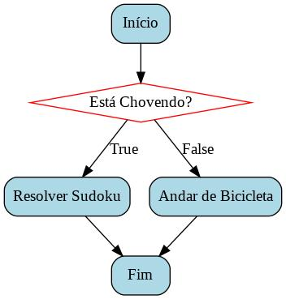

Esse fluxograma foi gerado automaticamente executando as duas células de código abaixo.

**Observação:** Apesar do livro texto ser independente de linguagem, alguns códigos nesta adaptação em Colab serão apresentados na linguagem de programação Python, pela facilidade didática na apresentação de conteúdos. Assim, os detalhes desses códigos não serão apresentados, pois fogem do escopo.

```python
!apt-get install graphviz libgraphviz-dev pkg-config
!pip install txtoflow
```

```python
from txtoflow import txtoflow

txtoflow.generate(
    '''
    Início;
    if (Está Chovendo?) {
        Resolver Sudoku;
    } else {
        Andar de Bicicleta;
    }
    Fim;
    '''
)
```

- Após executar a célula de código acima, visualize o arquivo `flowchart.jpg` clicando no ícone da pasta à esquerda.

## Condições com Lógica *Booleana*

- O resultado de um teste condicional sempre resultará em um valor *booleano*, isto é:
  - com dois resultados possíveis: **verdadeiro** ou **falso**
  - Por convenção: $True=1$ e $False=0$
- Portanto, para condições, **sempre usaremos combinações de operadores lógicos e relacionais** para verificar o estado das variáveis verificadas. O seguinte pseudocódigo exemplifica algumas condições:

```
se vai chover, então leve um guarda-chuva.

se é feriado, então fique em casa.

se estou atrasado e está chovendo, então chame um taxi.

se minha nota é menor que 5, então fiquei de recuperação.
```

- Note que para todas as condições acima, a resposta para a condição/pergunta é sempre: verdadeiro ou falso.
- Caso a condição seja verdadeira, será executada a operação ou operações especificadas na sequência.
- Codificando-se, as condições tomam a forma `se (condição) { comandos }`, como exemplos:

```
se (vai_chover) { leve um guarda-chuva }

se (feriado) { fique em casa }

se (atrasado e chovendo) { chame um taxi }

se (nota<5) { escrever “ficou de Recuperação” }
```

Esse código **fica melhor se usar a organização** apresentada no capítulo anterior:

```
se (vai_chover)
  leve um guarda-chuva

se (feriado)
  fique em casa

se (atrasado e chovendo)
  chame um taxi

se (nota<5)
  escrever “ficou de Recuperação”
```

- Observe que foram substituídas as chaves `{` e `}`, que definem os **escopos** das condicionais, pela tabulação. Isso é possível quando o bloco tem apenas uma instrução.
- Relembrando o Cap. 1 - Fundamentos, podemos usar nas **condicionais**, variáveis *booleanas* e operadores:
  - **relacionais**: ◦ == (é igual a) ◦ != (é diferente de) ◦ > (é maior que) ◦ < (é menor que) ◦ >= (é maior ou igual a) ◦ <= (é menor ou igual a)
  - Além de **lógicos**: ◦ && (e), & (e bit-a-bit) ◦ || (ou), | (ou bit a bit) ◦ ! (não lógico ou complemento) ◦ ~ (complemento bit-a-bit) ◦ ^ (ou exclusivo ‘XOR’ bit-a-bit)
- Os operadores **lógicos**, assim como os **relacionais**, sempre resultarão em **verdadeiro** (V) ou **falso** (F), mas os operandos também são *booleanos*.
- Para as condições contendo AND, OR e XOR (ou exclusivo), as **tabelas verdade** para os dois operandos à esquerda e à direita, com valores lógicos representados na primeira linha e na primeira coluna, são:

| && | V | F |
| --- | --- | --- |
| V | **V** | F |
| F | F | F |

| \ | \ |  | V |
| --- | --- | --- | --- |
| V | V | V |  |
| F | V | **F** |  |

| ^ | V | F |
| --- | --- | --- |
| V | F | V |
| F | V | F |

- Logo,
  - Os operandos devem ser ambos verdadeiros para que a operação AND retorne verdadeiro.
  - Pelo menos um deles deve ser verdadeiro para que o OR retorne verdadeiro.
  - Ambos devem ser diferentes para que o XOR (ou exclusivo `^`) retorne verdadeiro.
- Estas expressões, quando combinadas, resultarão sempre em um valor *booleano* V ou F, que pode então ser introduzido em um desvio condicional visando à realização de um subprograma.
- Existe também o operador **deslocamento** de bits:
  - `<< N` (shift-left, adiciona N zeros à direita do número em binário)
  - `>> N` (shift-right, elimina N dígitos à direita do número em binário)
- Por exemplo, usando os valores X=1, Y=2 e Z=4, qual é o resultado das expressões abaixo?
> 1. (X>0 && Y<2)
> 2. (Z>0 || Z<5 && Y==4)
> 3. (X>>1 ==0 || Y<<2>100)
> 4. (X!=0 && Y!=0 && Z<0)
> 5. (X=1)
- Dada a precedência de operadores estudada anteriormente e a combinação apresentada acima, apenas as expressões 2 e 3 resultariam em verdadeiro, dado $Z>0$, assim como $1>>1$ (*shift* à direita uma casa) em binário é 0; ambas são condições suficientes para que o resultado seja verdadeiro.

```python
X, Y, Z = 1, 2, 4
equacao1 = (X>0 and Y<2)
equacao2 = (Z>0 or Z<5 and Y==4)
equacao3 = (X>>1 ==0 or Y<<2>100)
equacao4 = (X!=0 and Y!=0 and Z<0)
#equacao5 = (X=1) # ERRO de sintaxe, deveria ser X==1
print(equacao1,equacao2,equacao3,equacao4)
```

```python
# Exemplo de uso do operador ">>" (shift à direita)
# O número 6 em binário é 1 1 0, que pode ser representado como 1*2^2 + 1*2^1 + 0*2^0

# Agora, aplicamos o operador de deslocamento à direita (">>") por 1 posição
resultado = 6 >> 1  # O resultado será 3
resultado
# Em binário, 3 é representado como 0 1 1 (1*2^1 + 1*2^0)
```

- É importante ressaltar a diferença entre os operadores de comparação `==`, com leitura `é igual à`, e de atribuição `=`, tendo a leitura `recebe o valor de`. Neste aspecto, a expressão 5 está incorreta, já que o operador de atribuição não faz sentido quando usado desta forma.

## Desvios Condicionais Simples e Compostos

```
se (condição) então faça
    Comandos

Volta para a parte sequencial
```

```
se (condição) então faça
    Comandos
senão faça
    Comandos

Volta para a parte sequencial
```

```
if (condição) {
    Comandos
}
```

```
if (condição) {
    Comandos
} else {
    Comandos
}
```

#### Exemplo 01 - Uso de Condicionais Simples

- Digamos que, como exemplo, desejamos calcular as raízes da equação de segundo grau usando a função `delta()` introduzida no capítulo anterior.
- Sabemos que as raízes dependem do sinal do $\Delta$.
- Logo, a solução de uma equação do segundo grau se dá resolvendo as seguintes condições:
> 1. Se $\Delta<0$, $x$ não possui raízes reais;
> 2. Se $\Delta=0$, $x$ possui duas raízes reais idênticas;
> 3. Se $\Delta>0$, $x$ possui duas raízes reais e distintas;
> 4. Calcule as raízes, se existirem, usando as equações:

$$x1 = -b+\frac{\sqrt{\Delta}}{2a}$$$$x2 = -b-\frac{\sqrt{\Delta}}{2a}$$

- Veja uma solução em pseudocódigo:

```
# a função é definida a seguir
função delta(a, b, c )
  retorne b * b - 4 * a * c

# programa principal
# ENTRADA DE DADOS
escreva("Calcula as raízes de equação de 2º grau: ax2 + bx + c")
real a = leia("Entre com o primeiro termo ‘a’: ")
real b = leia("Entre com o segundo  termo ‘b’: ")
real c = leia("Entre com o terceiro termo ‘c’: ")

# PROCESSAMENTO E SAÍDA
real d = delta(5, -2, 4)
escreva(“O delta é ” + valor)
se (d < 0)
  escreva("A equação não possui raízes reais")
se (d == 0)
  escreva("A raíz é " + (-b + raíz(d)/2*a))
se (d > 0)
  escreva("As raízes são x1=" + (-b - raíz(d)/2*a)) + " e x2="  +
  (-b + raíz(d)/2*a))
```

###### Casos para Teste Moodle+VPL

Para o professor criar uma atividade VPL no Moodle para este Exemplo 01, basta incluir em `Casos para teste`, o seguinte texto (pode incluir mais casos):

```
case=caso1
input=3
1
4
output=
O delta é  -47.0
A equação não possui raízes reais.
case=caso2
input=4
6
2
output= O delta é 4.0
Raízes: -10.0 e -2.0.
```

Observe que no código abaixo foram criadas funções de entrada `leia()` e de saída `escreva()`.

```python
%%writefile cap3ex01.java
class cap3ex01 {

    public static void main(String[] args) {

        // ENTRADA DE DADOS
        escreva("Resolve equação de 2º grau: ax^2 + bx + c\n");
        double a = leia("Entre com o primeiro termo 'a': ");
        double b = leia("Entre com o segundo  termo 'b': ");
        double c = leia("Entre com o terceiro termo 'c': ");

        // PROCESSAMENTO E SAÍDA
        double d = delta(a, b, c);
        String res = "O delta é " + d + "\n";
        if (d < 0) {
            res += "A equação não possui raízes reais";
        }
        if (d == 0) {
            res += "Raíz: " + (-b + Math.sqrt(d) / 2 * a);
        }
        if (d > 0) {
            res += "Raízes: "
                    + (-b - Math.sqrt(d) / 2 * a) + " e "
                    + (-b + Math.sqrt(d) / 2 * a);
        }
        escreva(res + ".\n"); // exibe sentença e pula linha
    }

    public static double delta(double a, double b, double c) {
        return b * b - 4 * a * c;
    }

    public static float leia(Object texto) {
        System.out.print(texto);
        return new java.util.Scanner(System.in).nextFloat();
    }

    static void escreva(Object o) {
        System.out.print(o);
    }
}
```

```python
!javac cap3ex01.java
!java cap3ex01
```

```python
# solução 1
%%writefile cap3ex01.js
function escreva(s) {try {element.append(s)} catch(e) {try {document.write(s)} catch(e) {console.log(s)}}}
const leia = (name) => {return `${name}`}

function delta(a, b, c) {
  var d = b * b - 4 * a * c;
  return d;
}

// ENTRADAS
var a = leia(process.argv[2]) // ATENÇÃO NESTA INSTRUÇÃO!
var b = leia(process.argv[3]) // ATENÇÃO NESTA INSTRUÇÃO!
var c = leia(process.argv[4]) // ATENÇÃO NESTA INSTRUÇÃO!

// PROCESSAMENTO E SAÍDA
var d = delta(a, b, c);
var res = "O delta é " + d.toFixed(1) + "\n";
if (d < 0) {
    res += "A equação não possui raízes reais";
}
if (d == 0) {
    res += "Raíz: " + (-b + Math.sqrt(d) / 2 * a);
}
if (d > 0) {
    res += "Raízes: "
            + (-b - Math.sqrt(d) / 2 * a) + " e "
            + (-b + Math.sqrt(d) / 2 * a);
}
escreva(res + ".\n"); // exibe sentença e pula linha
```

```python
%%shell
node cap3ex01.js 4 5 2
```

Código para executar em atividades no Moodle+VPL. Testar códigos antes de submeter para avaliação, por exemplo, em https://www.jdoodle.com/execute-nodejs-online.

```python
# solução 2 para executar no Moodle+VPL
%%writefile cap3ex01.js
function escreva(s) {try {element.append(s)} catch(e) {try {document.write(s)} catch(e) {console.log(s)}}}
function leia(linhas,i) {return linhas.toString()}

function delta(a, b, c) {
  var d = b * b - 4 * a * c;
  return d;
}

process.stdin.once('data', linhas => {

  // ENTRADAS
  var a = leia(process.argv[2]) // ATENÇÃO NESTA INSTRUÇÃO!
  var b = leia(process.argv[3]) // ATENÇÃO NESTA INSTRUÇÃO!
  var c = leia(process.argv[4]) // ATENÇÃO NESTA INSTRUÇÃO!

  // PROCESSAMENTO E SAÍDA
  var d = delta(a, b, c);
  var res = "O delta é " + d.toFixed(1) + "\n";
  if (d < 0) {
      res += "A equação não possui raízes reais";
  }
  if (d == 0) {
      res += "Raíz: " + (-b + Math.sqrt(d) / 2 * a);
  }
  if (d > 0) {
      res += "Raízes: "
              + (-b - Math.sqrt(d) / 2 * a) + " e "
              + (-b + Math.sqrt(d) / 2 * a);
  }
  escreva(res + ".\n"); // exibe sentença e pula linha
})
```

```python
# NÃO EXECUTA NESTE COLAB, SOMENTE NO MOODLE+VPL
%%shell
#node cap3ex01.js 4 5 2
```

```python
%%writefile cap3ex01.c
#include <stdio.h>
#include <math.h>
float delta(float a, float b, float c) {
  float d = b*b-4*a*c;
  return d;
}

float leia() {
  float valor;
  printf("Entre com um valor: ");
  scanf("%f", &valor);
  return valor;
}

int main(void) {

  // ENTRADAS
  float a, b, c;
  a = leia();
  b = leia();
  c = leia();

  // PROCESSAMENTO e SAÍDA
  double d = (double) delta(a, b, c);
  printf("Delta = %.1f\n", d);
  if (d < 0) {
      printf("A equação não possui raízes reais");
  }
  if (d == 0) {
      printf("Raíz: %.1f",(-b + sqrt(d) / 2 * a));
  }
  if (d > 0) {
      printf("Raíz: %.1f e %.1f ",(-b - sqrt(d) / 2 * a), (-b + sqrt(d) / 2 * a));
  }
  return 0;
}
```

```python
%%shell
gcc -Wall -std=c99 cap3ex01.c -o output2 -lm
./output2
# A biblioteca matemática deve ser vinculada ao construir o executável.
# Como fazer isso varia de acordo com o ambiente,
# mas no Linux / Unix, basta adicionar -lm ao comando
```

#### Exemplo 02 - Uso de Condicionais Compostas e Encadeadas

- Considere o seguinte pseudocódigo para ler duas notas reais, calcular a média das duas notas e atribui um conceito:

```
nota1 = leia("Digite a 1a nota:");
nota2 = leia("Digite a 2a nota:");
media = (nota1 + nota2)/2;
se media >= 9 então
    escreva("Conceito A");
senão se media >= 7.5
    escreva("Conceito B");
senão se media >= 6
    escreva("Conceito C");
senão se media >= 5|
    escreva("Conceito D");
senão
    escreva("Reprovado! Conceito F");
```

- Ver Fluxograma abaixo (também experimente nessa ferramenta *online*: [code2flow](https://app.code2flow.com/), copiando e colando o código em vermelho abaixo):

[figure not shown]

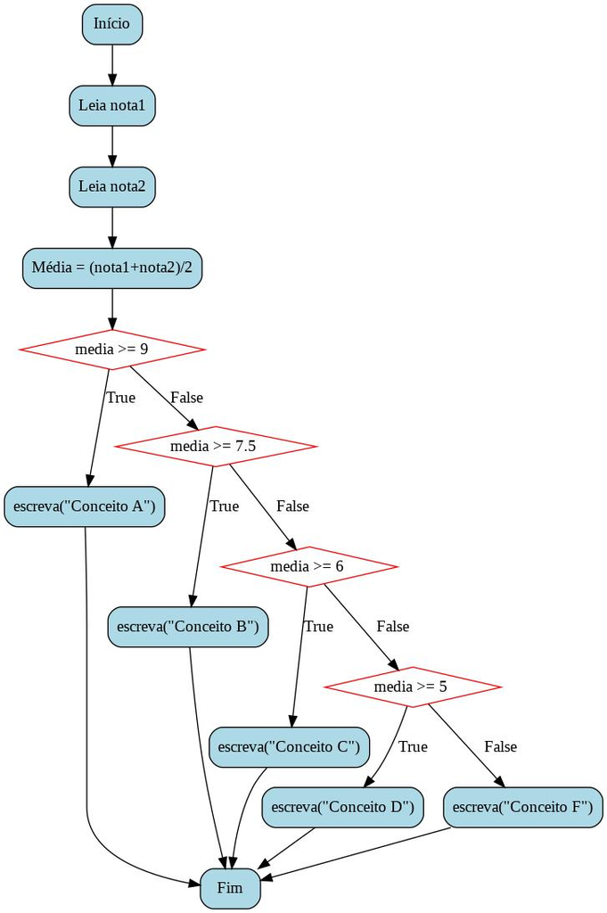

Esse fluxograma foi gerado automaticamente ao executar as duas células de código abaixo.

```python
from txtoflow import txtoflow

txtoflow.generate(
    '''
    Início;
    Leia nota1;
    Leia nota2;
    Média = (nota1+nota2)/2;
    if ( media >= 9 ) {
        escreva("Conceito A");
    } else if (media >= 7.5 ) {
        escreva("Conceito B");
    } else if (media >= 6 ) {
        escreva("Conceito C");
    } else if (media >= 5 ) {
        escreva("Conceito D");
    } else {
        escreva("Conceito F");
    }
    Fim;
    '''
)
```

- Após executar a célula de código acima, ver o arquivo `flowchart.jpg` clicando no ícone de pasta à esquerda.

###### Casos para Teste Moodle+VPL

Para o professor criar uma atividade VPL no Moodle para este Exemplo 02, basta incluir em `Casos para teste`, o seguinte texto (pode incluir mais casos):

```
case=caso1
input=4.0
6.0
output=
Conceito D
case=caso2
input=4.0
5.0
output=
Conceito F
case=caso2
input=5.0
7.0
output=
Conceito C
case=caso3
input=6.0
9.0
output=
Conceito B
case=caso4
input=9.0
10.0
output=
Conceito A
```

Em Java, uma função retorna um valor, ou uma estrutura, como vetor.

```python
%%writefile cap3ex02.java
import java.util.Scanner;
class cap3ex02 {
  public static void main(String[] args) {

    // ENTRADAS
    Scanner teclado1 = new Scanner(System.in);
    float nota1 = teclado1.nextFloat();
    float nota2 = teclado1.nextFloat();

    // PROCESSAMENTO E SAÍDA
    float media = (nota1 + nota2)/2;
    if (media >= 9.0)
      System.out.print("Conceito A");
    else if (media >= 7.5)
      System.out.print("Conceito B");
    else if (media >= 6.0)
      System.out.print("Conceito C");
    else if (media >= 5.0)
      System.out.print("Conceito D");
    else
      System.out.print("Reprovado! Conceito F.");
  }
}
```

```python
!javac cap3ex02.java
!java cap3ex02
```

Código para executar em atividades no Moodle+VPL. Testar códigos antes de submeter para avaliação, por exemplo, em https://www.jdoodle.com/execute-nodejs-online.

```python
# Para executar no Moodle+VPL
%%writefile cap3ex02.js
function escreva(s) {try {element.append(s)} catch(e) {try {document.write(s)} catch(e) {console.log(s)}}}
function leia(linhas,i) {return linhas.toString().split('\n')[i]}

process.stdin.once('data', linhas => {

    // ENTRADAS
    var nota1 = parseFloat(leia(linhas,0)) // ATENÇÃO NESTA INSTRUÇÃO!
    var nota2 = parseFloat(leia(linhas,1)) // ATENÇÃO NESTA INSTRUÇÃO!

    // PROCESSAMENTO e SAÍDA
    var media = (nota1 + nota2)/2;
    if (media >= 9.0)
      escreva("Conceito A");
    else if (media >= 7.5)
      escreva("Conceito B");
    else if (media >= 6.0)
      escreva("Conceito C");
    else if (media >= 5.0)
      escreva("Conceito D");
    else
      escreva("Reprovado! Conceito F.");
})
```

```python
%%shell
#node cap3ex02 3 4 2
```

```python
%%writefile cap3ex02.c
#include <stdio.h>
float leia() {
  float valor;
  printf("Entre com um valor: ");
  scanf("%f", &valor);
  return valor;
}

int main(void) {

  // ENTRADAS
  float nota1 = leia();
  float nota2 = leia();

  // PROCESSAMENTO E SAÍDA
  float media = (nota1 + nota2)/2;
  if (media >= 9.0)
    printf("Conceito A");
  else if (media >= 7.5)
    printf("Conceito B");
  else if (media >= 6.0)
    printf("Conceito C");
  else if (media >= 5.0)
    printf("Conceito D");
  else
    printf("Reprovado! Conceito F.");
  return 0;
}
```

```python
%%shell
gcc -Wall -std=c99 cap3ex02.c -o output2
./output2
```

## Comando `switch`

O `switch` verifica se uma variável (do tipo `int` ou `char`) é ou não igual a certo valor constante (`valor1`, `valor2`, ..., `valorN` na sintaxe a seguir):

```
switch (variável) {
  case valor1:
    Comandos;
    break;
  case valor2:
    Comandos;
    break;
  case valorN:
    Comandos;
    break;
  default: // opcional, caso não ocorram os casos anteriores
    Comandos;
}
```

O comando `switch` é útil quando se tem um menu de opções a ser executado.

#### Exemplo 03 - Exemplo de `switch` com menu de opções

```python
%%writefile cap3ex03.c
#include <stdio.h>
int main() {
  float area;
  int num;
  char escolha;
  printf("1. Circulo\n");
  printf("2. Quadrado\n");
  printf("Escolha:\n");

  scanf("%c", &escolha);

  switch (escolha) {
  case '1':
    printf("Raio:\n");
    scanf("%d", &num);
    area = 3.14 * num * num;
    printf("Area do circulo: ");
    printf("%.2f\n", area);
    break;

  case '2':
    printf("Lado:\n");
    scanf("%d", &num);
    area = num * num;
    printf("Area do quadrado: ");
    printf("%.2f\n", area);
    break;

  default:
    printf("Escolha Incorreta!\n");
  }
  return 0;
}
```

```python
%%shell
gcc -Wall -std=c99 cap3ex03.c -o output3
./output3
```

Copie o código e depure-o. Por exemplo, você pode usar opções de depuração *online*, como as seguintes:

- https://pythontutor.com
- https://vscode.dev/

## Exercícios

Para visualizar o *notebook* Colab no arquivo `cap3.part2.lab.*.ipynb` (`X` $\in$ `[2,3,4,...]` e `*` é a extensão da linguagem), você pode utilizar a linguagem de programação de sua preferência e organizar os *notebooks* nas subpastas contidas na pasta **"gen"** dentro da pasta do Google Drive "colabs", acessível através deste [link](https://drive.google.com/drive/folders/1YlFwv8XYN7PYYf-HwDMlkxzbmXzJw9cM?usp=sharing).

## Revisão deste capítulo de Desvios Condicionais

- O que é um desvio condicional?
- Condições com lógica booleana
- Desvios condicionais simples e compostos, com encadeamentos
- Exercícios
- Revisão deste capítulo de Desvios Condicionais

## Processando a Informação: Cap. 3: Desvios Condicionais - Prática 1

[figure not shown]

Este caderno (*Notebook*) é uma parte complementar *online* do livro **[Processando a Informação](https://editora.ufabc.edu.br/matematica-e-ciencias-da-computacao/58-processando-a-informacao): um livro prático de programação independente de linguagem**, que deve ser consultado em caso de dúvidas sobre os temas apresentados.

> Este conteúdo pode ser copiado e alterado livremente, sendo inspirado por este livro.

### Exercícios

1. Crie um método com apenas condicionais e o operador resto (%) para:
- Determinar se um número entrado pelo teclado é par ou ímpar, exibindo a mensagem apropriada na tela;
- Modifique o método anterior para verificar se o número entrado é múltiplo de 3.

Teste em um programa principal várias chamadas destes métodos.

2. Faça um programa que leia (peça para o usuário digitar) três números inteiros quaisquer, armazenando nas variáveis A, B e C e imprima os números em ordem do menor para o maior.
3. Faça um programa que receba três valores inteiros nas variáveis A, B e C e ordene os valores nas próprias variáveis, de forma que, no final da execução, a variável A contenha o menor valor e C o maior valor. O programa deve usar apenas 4 variáveis: A, B, C e T.
4. Faça um programa em qualquer linguagem para determinar a classificação do peso de um indivíduo, de acordo com a tabela:

| Tabela: IMC = peso / altura2|| |:-: |:-: | |Magro|IMC até 18,5 | |Saudável|IMC até 25,0| |Acima do peso|IMC até 30,0| |Obeso|IMC até 35,0| |Morbidez|IMC 35 mais|

5. Faça um programa para ler três notas (nota1, nota2 e nota3, com pesos 3, 3 e 4, respectivamente), calcular a média ponderada, fazer a conversão para conceito, conforme critérios definidos no Cap. 3.

## Processando a Informação: Cap. 3: Desvios Condicionais - Prática 2

[figure not shown]

Este caderno (*Notebook*) é uma parte complementar *online* do livro **[Processando a Informação](https://editora.ufabc.edu.br/matematica-e-ciencias-da-computacao/58-processando-a-informacao): um livro prático de programação independente de linguagem**, que deve ser consultado em caso de dúvidas sobre os temas apresentados.

> Este conteúdo pode ser copiado e alterado livremente, sendo inspirado por este livro.

### Exercícios

[Fonte: [link](https://www.studocu.com/pt-br/document/universidade-estadual-da-paraiba/algoritmos/tarefas-obrigatorias/lista-de-exercicio-respondido-em-python-estrutura-condicional/4958982/view)]

1. Fazer um programa que leia a capacidade de um elevador e o peso de 5 pessoas. Informar se o elevador está liberado para subir ou se excedeu a carga máxima.
2. Faça um programa que leia 4 variáveis A, B, C e D. A seguir, se B for maior do que C e se D for maior do que A e a soma de C com D for maior que a soma de A e B e se C e D, ambos, forem positivos e se a variável A for par, escrever a mensagem “valores aceitos”, senão escrever “valores não aceitos”
3. Escreva um programa que informe se um dado ano é ou não é bissexto. Um ano é bissexto se ele for divisível por 400 ou se ele for divisível por 4 e não por 100.
4. Construa um programa que leia um número inteiro e imprima a quantidade de centenas, dezenas e unidades desse número. Considere o seguinte exemplo: o número 345 possui 3 centenas, 4 dezenas e 5 unidades.
5. Faça um programa que pergunte o nome do aluno, a quantidade de dias na semana e o tipo de curso (B para básico, I para intermediário e A para avançado). Mostre o nome do aluno e o valor a ser pago. O valor total é calculado com base nas informações abaixo:
- Caso a opção escolhida for Básico, deverá fazer a seguinte conta:

> Valor Total = (Quantidade de dias na semana * 7 ) * 15
- Caso a opção escolhida for Intermediário, deverá fazer a seguinte conta:

> Valor Total = (Quantidade de dias na semana * 8,5 ) * 20
- Caso a opção escolhida for Avançado, deverá fazer a seguinte conta:

> Valor Total = (Quantidade de dias na semana * 10 ) * 25

## Processando a Informação: Cap. 3: Desvios Condicionais - Prática 3

[figure not shown]

Este caderno (*Notebook*) é uma parte complementar *online* do livro **[Processando a Informação](https://editora.ufabc.edu.br/matematica-e-ciencias-da-computacao/58-processando-a-informacao): um livro prático de programação independente de linguagem**, que deve ser consultado em caso de dúvidas sobre os temas apresentados.

> Este conteúdo pode ser copiado e alterado livremente, sendo inspirado por este livro.

### Exercícios

[Fonte: [link](http://www.facom.ufu.br/~backes/gbt017/ListaPython02.pdf)]

1. Faça um programa que leia 2 notas de um aluno, verifique se as notas sao válidas e

exiba na tela a média destas notas. Uma nota válida deve ser, obrigatoriamente, um valor entre 0.0 e 10.0, onde caso a nota não possua um valor válido, este fato deve ser informado ao usuário e o programa termina.

2. Escreva um programa que leia um número inteiro maior do que zero e devolva, na tela, a soma de todos os seus algarismos. Por exemplo, ao numero 251 corresponder ao valor 8 (2 + 5 + 1). Se o numero lido não for maior do que zero, o programa terminará com a mensagem “Numero inválido”.
3. Escreva um programa que leia um inteiro entre 1 e 12 e imprima o mês correspondente a este número. Isto é, janeiro se 1, fevereiro se 2, e assim por diante.
4. Faça uma função que calcule e retorne a área de um trapézio (A). Lembre-se que a base maior e a base menor devem ser números maiores que zero.

$$ A = \frac{altura*(basemaior + basemenor)}{2}$$

5. Faça um programa para verificar se um determinado número inteiro e divisível por 3 ou 5, mas nao simultaneamente pelos dois.
6. Escreva o menu de opções abaixo. Leia a opção do usuário e execute a operação escolhida. Escreva uma mensagem de erro se a opção for inválida.

```
Escolha a opção:
1- Soma de 2 números.
2- Diferença entre 2 números (maior pelo menor).
3- Produto entre 2 números.
4- Divisão entre 2 números (o denominador não pode ser zero).
Opção
```

7. Leia a idade e o tempo de serviço de um trabalhador e escreva se ele pode ou não se aposentar. As condições para aposentadoria são:
- Ter pelo menos 65 anos,
- Ou ter trabalhado pelo menos 30 anos,
- Ou ter pelo menos 60 anos e trabalhado pelo menos 25 anos.
8. Uma empresa vende o mesmo produto para quatro diferentes estados. Cada estado possui uma taxa diferente de imposto sobre o produto (MG 7%; SP 12%; RJ 15%; MS 8%). Faça um programa em que o usuario entre com o valor e o estado destino do produto e o programa retorne o preço final do produto acrescido do imposto do estado em que ele será vendido. Se o estado digitado não for válido, mostrar uma mensagem de erro.
9. Leia a distância em Km e a quantidade de litros de gasolina consumidos por um carro em um percurso, calcule o consumo em Km/l e escreva uma mensagem de acordo com a tabela abaixo:

| Consumo | Km/l | Mensagem | |----------- |-------- |------------------ | | menor que | 8 | venda o carro! | | entre | 8 e 14 | econômico! | | maior que | 14 | super econômico! |

10. Escreva um programa que, dada a idade de um nadador, classifique-o em uma das seguintes categorias:

| Categora | Idade | |----------- |-------- | | Infantil A | 5 a 7 | | Infantil B | 8 a 10 | | Juvenil A | 11 a 13 | | Juvenil B | 14 a 17 | | Sênior | maior que 17 |

11. Escrever um programa que leia o codigo do produto escolhido do cardápio de uma lanchonete e a quantidade. O programa deve calcular o valor a será pago por aquele lanche.

Considere que a cada execução somente será calculado um pedido. O cardápio da lanchonete segue o padrao abaixo:

| Especificação | Código | Preço | |----------- |-------- |-------| | Cachorro quente | 100 | 12.0 | | Bauru Simples | 101 | 13.0 | | Bauru Simples | 102 | 13.0 | | Hamburguer | 103 | 12.0 | | Cheeseburguer | 104 | 17.0 | | Suco | 105 | 6.0 | | Refrigerante | 106 | 4.0 |

# Processando a Informação: Cap. 4: Estruturas de Repetição (Laços)

[figure not shown]

Este caderno (*Notebook*) é uma parte complementar *online* do livro **[Processando a Informação](https://editora.ufabc.edu.br/matematica-e-ciencias-da-computacao/58-processando-a-informacao): um livro prático de programação independente de linguagem**, que deve ser consultado em caso de dúvidas sobre os temas apresentados.

> Este conteúdo pode ser copiado e alterado livremente, sendo inspirado por este livro.

## Sumário

- Revisão do capítulo anterios
- Quando usar repetições?
- Tipos de estruturas de repetição
- Laços aninhados
- Validação de dados com laços
- Interrupção da execução dos laços
- Recursão
- Revisão deste capítulo
- Exercícios

## Revisão do capítulo anterior (Desvios Condicionais)

- No capítulo anterior foram apresentadas formas de construir código contendo estruturas condicionais simples ou compostas. Ou seja, desvios condicionais, da forma:
  - `se` algo for verdade, `então`
    - faça algo1,
  - `senão` # essa parte é opcional
    - faça algo2.
- Neste capítulo iremos abordar as **Estruturas de Repetição**, conhecidas também como **Laços** ou ***Loops***.

## Quando usar repetições?

- As estruturas de repetição são recomendadas quando um padrão de código é repetido várias vezes sequencialmente, alterando apenas o valor de uma ou mais variáveis entre os comandos repetidos.
- Veja no exemplo a seguir um pseudocódigo para imprimir a tabuada de um número `t` inserido pelo usuário no formato:

Tabuada x (número de 1 a 10) = valor

```
Inteiro: t, n = 1;
t = leia("Qual a tabuada? ");
escreva(t + " x " + n + " = " + t * n);
n = n + 1;
escreva(t + " x " + n + " = " + t * n);
n = n + 1;
escreva(t + " x " + n + " = " + t * n);
n = n + 1;
escreva(t + " x " + n + " = " + t * n);
n = n + 1;
escreva(t + " x " + n + " = " + t * n);
n = n + 1;
escreva(t + " x " + n + " = " + t * n);
n = n + 1;
escreva(t + " x " + n + " = " + t * n);
n = n + 1;
escreva(t + " x " + n + " = " + t * n);
n = n + 1;
escreva(t + " x " + n + " = " + t * n);
n = n + 1;
escreva(t + " x " + n + " = " + t * n);
n = n + 1;
```

- Embora o código não pareça extenso, é fácil imaginar uma situação em que seja necessário repetir um mesmo bloco de instruções 100, 500 ou até 1000 vezes.

## Tipos de estruturas de repetição

### Pseudocódigo

#### faça-enquanto

```
faça {
  comandos
} enquanto (condição);
```

#### enquanto-faça

```
enquanto (condição) faça {
  comandos
}
```

#### para

```
para variável = valor_inicial até valor_final, variável++, faça {
  comandos
}
```

#### para reverso

```
para variável = valor_final até valor_inicial, variável--, faça {
  comandos
}
```

- A forma `faça-enquanto` é recomendada quando queremos que os comandos contidos no laço sejam executados ao menos uma vez, mesmo que a condição seja inicialmente falsa.
- Note que no caso do `enquanto-faça` é necessário que a condição seja verdadeira para que os comandos presentes no bloco de execução sejam processados.
  - Neste caso, se ao entrar no comando `enquanto` (*while*) a condição do teste for falsa, oposto ao `faça-enquanto`, o subprograma não será executado.
  - Isto é, todo o código dentro do bloco do laço será pulado já na verificação inicial da condição no `enquanto-faça`, seguindo diretamente para a parte sequencial subsequente, similar ao que ocorre no `se-então`.
- O laço `para` é recomendado quando se sabe o número de iterações existentes (quantas vezes o bloco dentro do laço será executado). Por exemplo, no caso anterior do problema da Tabuada.

### C/CPP/Java/JavaScript

#### do-while

```
do {
  comandos;
} while (condição);
```

#### while

```
while (condição) {
  comandos;
}
```

#### for

```
for(v=0; v<10; v++) {
  comandos;
}
```

Em algumas linguagens de programação é possível omitir um ou todos os parâmetros, por exemplo: `for(;;) {...}`.

### Pseudocódigo: Exemplo laço faça-enquanto.

```
Real: nota, média, acumulador = 0, contador = 0;
Caractere: resposta = 'lixo';

faça {
   nota = leia("Entre com uma nota: ");
   acumulador = acumulador + nota;
   contador = contador + 1;
   resposta = leia("Deseja continuar? (s/n): ");
} enquanto (resposta == 's');

média = acumulador / contador;
imprima("A média das " + contador + " notas é " + média);
```

- Além do `contador`, o programa utiliza um `acumulador` (variável que acumula as notas digitadas).
- Repare que a condição `resposta == 's'` no `faça-enquanto` é inicialmente falsa (igual a `'lixo'`) até que seja efetuada a leitura da variável resposta com dentro do laço, em: `resposta = leia("Deseja continuar? (s/n): ");`
- Apenas no caso de o usuário entrar com o caractere `'s'`, o laço será repetido novamente.

### Pseudocódigo: Exemplo laço enquanto-faça.

```
Real: nota, média, acumulador = 0, contador = 0;
Caractere: resposta = 's';

enquanto (resposta == 's') faça {
   nota = leia("Entre com uma nota: ");
   acumulador = acumulador + nota;
   contador = contador + 1;
   resposta = leia("Deseja continuar? (s/n): ");
}

média = acumulador / contador;
imprima("A média das " + contador + " notas é " + média);
```

- Observe que no pseudocódigo anterior do `enquanto-faça` temos o mesmo resultado do `faça-enquanto`, pois a variável `resposta` é inicializada com `s`, satisfazendo a condição lógica e entrando no laço.
- Ver Fluxograma abaixo (também experimente nessa ferramenta *online*: [code2flow](https://app.code2flow.com/), copiando e colando o código em vermelho abaixo):

[figure not shown]

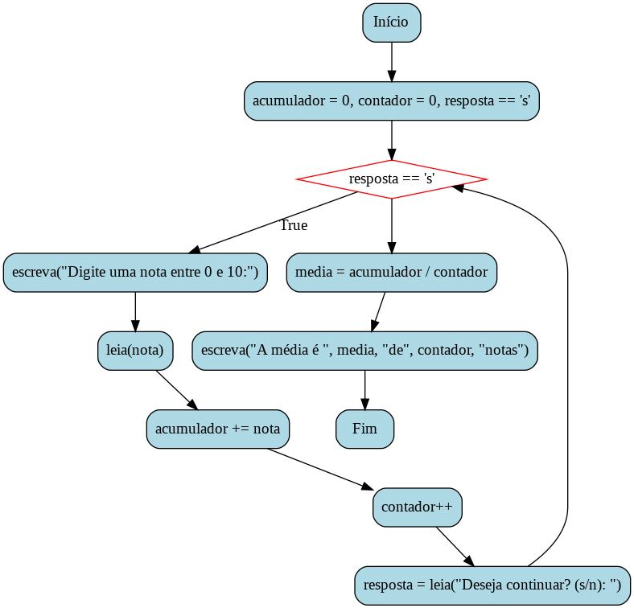

```python
!apt-get install graphviz libgraphviz-dev pkg-config
!pip install txtoflow
```

```python
from txtoflow import txtoflow

txtoflow.generate(
    '''
    Início;
    acumulador = 0, contador = 0, resposta == 's';
    while (resposta == 's') {
      escreva("Digite uma nota entre 0 e 10:");
      leia(nota);
      acumulador += nota;
      contador++;
      resposta = leia("Deseja continuar? (s/n): ");
    }
    media = acumulador / contador;
    escreva("A média é ", media, "de", contador, "notas");
    Fim;
    '''
)
```

### Pseudocódigo: Exemplo de laço enquanto-faça INFINITO.

Considere uma alteração no código anterior para não fazer mais a pergunta `Deseja continuar? (s/n)`, mas entrando num laço `enquanto-faça` para ler e acumular 100 notas:

```
Real: nota, média, acumulador = 0, contador = 0;

enquanto (contador < 100) faça {
   nota = leia("Entre com uma nota: ");
   acumulador = acumulador + nota;
   # contador = contador + 1;
}

média = acumulador / contador;
imprima("A média das " + contador + " notas é " + média);
```

- O que vai ocorrer ao escrever e executar esse código em alguma linguagem de programação?
- Onde está o erro?
- **MUITO CUIDADO COM LAÇOS INFINITOS EM ATIVIDADES NO MOODLE+VPL!** Se a execução demorar mais que 1 minuto, provavelmente entrou em um laço infinito e terá que recarregar a página.
- Esta condição, onde a execução fica “presa” dentro do laço, é conhecida como ***DEADLOCK***.
- *Deadlocks* geram erro de finalização de programa, que executará eternamente, podendo travar o programa, o teclado e o mouse ou até mesmo o computador, neste caso, sendo necessário um ***RESET*** para sair do laço.

## Validação de Dados

- Uma possível aplicação de laços é garantir que os dados entrados sejam válidos.
- **Validação de dados** é o nome dado à verificação dos valores de entrada, se os mesmos se encontram dentro dos limites previstos ou no formato adequado, notificando o usuário no caso de valores inválidos.
- O exemplo a seguir é o pseudocódigo apresentado anteriormente, incorporando a validação de dados de entrada (nota entre 0 e 10), indicando o erro e pedindo para o usuário entrar novamente o dado até que seja válido.

### Pseudocódigo: Exemplo de laço faça-enquanto, com validação

```
plaintext
Real: nota, média, acumulador = 0, contador = 0;
Caractere: resposta = 'lixo';

faça {
  faça {
    nota = leia("Entre com uma nota entre 0 e 10: ");
    se (nota < 0 || nota > 10) então
      escreva("ERRO, nota inválida. Digite uma nota entre 0 e 10!")
  } enquanto (nota < 0 || nota > 10);
  acumulador = acumulador + nota;
  contador = contador + 1;
  resposta = leia("Deseja continuar? (s/n): ");
} enquanto (resposta == 's');

média = acumulador / contador;
imprima("A média das " + contador + " notas é " + média);
```

- No pseudocódigo anterior, o segundo `faça-enquanto` aceita apenas notas entre 0 e 10. Caso contrário, escreve uma mensagem de erro e solicita nova nota.
- Ver Fluxograma abaixo (também experimente nessa ferramenta *online*: [code2flow](https://app.code2flow.com/), copiando e colando o código em vermelho abaixo).
- Observar que essa biblioteca `txtoflow` não aceita `faça-enquanto`, assim como o Python.

[figure not shown]

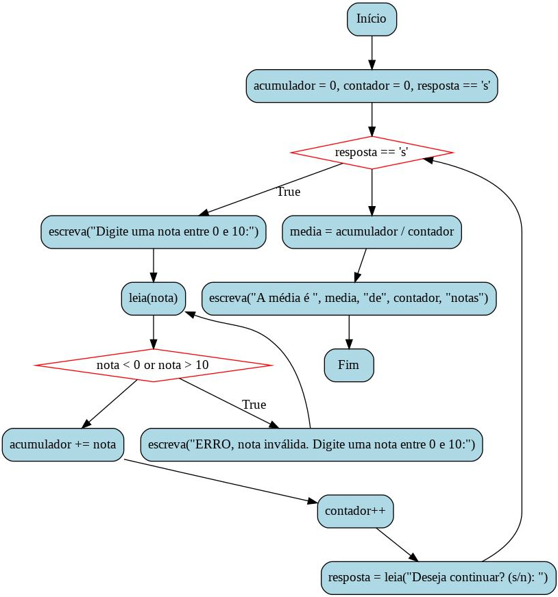

```python
!apt-get install graphviz libgraphviz-dev pkg-config
!pip install txtoflow
```

```python
from txtoflow import txtoflow

txtoflow.generate(
    '''
    Início;
    acumulador = 0, contador = 0, resposta == 's';
    while (resposta == 's') {
      escreva("Digite uma nota entre 0 e 10:");
      leia(nota);
      while (nota < 0 or nota > 10) {
        escreva("ERRO, nota inválida. Digite uma nota entre 0 e 10:");
        leia(nota);
      }
      acumulador += nota;
      contador++;
      resposta = leia("Deseja continuar? (s/n): ");
    }
    media = acumulador / contador;
    escreva("A média é ", media, "de", contador, "notas");
    Fim;
    '''
)
```

## Interrupção dos laços

- Algumas linguagens permitem interromper a execução do laço através do comando ‘interromper’ ou ‘quebrar’ (**break**).
- Isto pode ser útil caso se queira interromper o laço em algum evento específico.

## Exemplo 01 - Ler 10 notas com validação

Considere um algoritmo para ler 10 notas válidas, entre 0 e 10, escrevendo no final a média nas notas válidas lidas.

###### Pseudocódigo

```
Real: nota, média, acumulador = 0, contador = 0;

escreva("Entre com 10 notas válidas")
faça {
  faça {
    nota = leia();
  } enquanto (nota < 0 || nota > 10);
  acumulador = acumulador + nota;
  contador = contador + 1;
} enquanto (contador < 10);

média = acumulador / contador;
escreva("A média das " + contador + " notas é " + média);
```

- Ver Fluxograma abaixo (também experimente nessa ferramenta *online*: [code2flow](https://app.code2flow.com/), copiando e colando o código em vermelho abaixo):

[figure not shown]

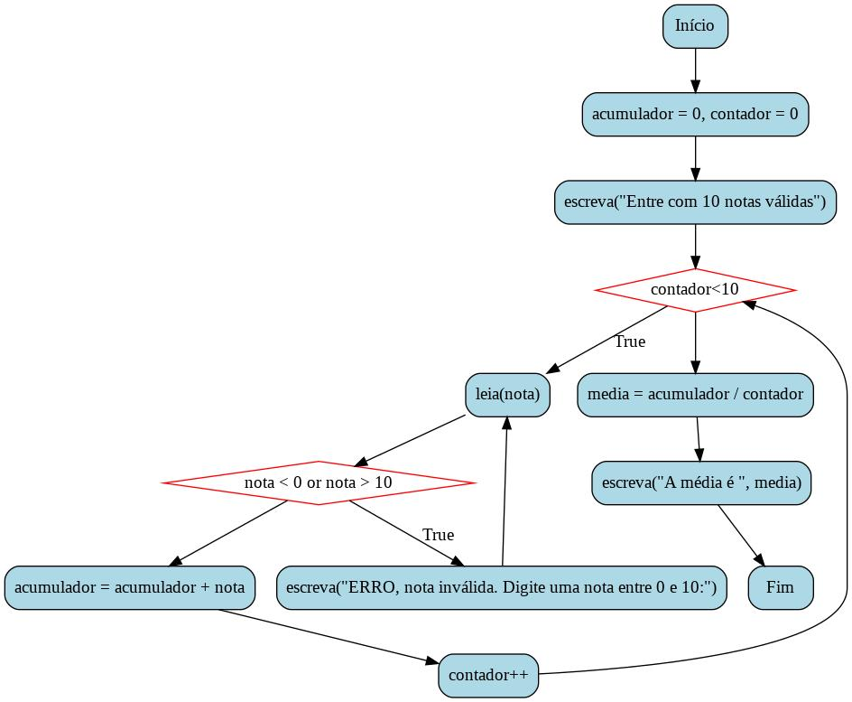

```python
!apt-get install graphviz libgraphviz-dev pkg-config
!pip install txtoflow
```

```python
from txtoflow import txtoflow

txtoflow.generate(
    '''
    Início;
    acumulador = 0, contador = 0;
    escreva("Entre com 10 notas válidas");
    while (contador<10) {
      leia(nota);
      while (nota < 0 or nota > 10) {
        escreva("ERRO, nota inválida. Digite uma nota entre 0 e 10:");
        leia(nota);
      }
      acumulador = acumulador + nota;
      contador++;
    }
    media = acumulador / contador;
    escreva("A média é ", media);
    Fim;
    '''
)
```

###### Casos para Teste Moodle+VPL

Para o professor criar uma atividade VPL no Moodle para este Exemplo 01, basta incluir em `Casos para teste`, o seguinte texto (pode incluir mais casos):

```
case=caso1
input=9.0
78.0
6.0
9
8
7
6
5
7
8
6
output=
A média das 10 notas é 7.1
case=caso2
input=9.0
78.0
-9.0
9876.0
9876.0
7.0
9
8
4
6
6
8
9
7
output=
A média das 10 notas é 7.3
```

```python
%%writefile cap4ex01.java
import java.util.Scanner;
class cap4ex01 {
  public static void main(String[] args) {

    // ENTRADA DE DADOS e PROCESSAMENTO
    float acumulador = 0, nota, media;
    int contador = 0;
    Scanner teclado1 = new Scanner(System.in);

    System.out.println("Entre com 10 notas válidas");
    while (contador<10) {
      do {
          nota = teclado1.nextFloat();
      } while (nota < 0 || nota > 10 );
      acumulador += nota;
      contador++;
    }
    media = acumulador/contador;
    // SAÍDA
    System.out.print("A média das " + contador + " notas é " + media);
  }
}
```

```python
!javac cap4ex01.java
!java cap4ex01
```

Código para executar em antividades no Moodle+VPL. Testar códigos antes de submeter para avaliação, por exemplo, em https://www.jdoodle.com/execute-nodejs-online.

```python
%%writefile cap4ex01.js
function escreva(s) {try {element.append(s)} catch(e) {try {document.write(s)} catch(e) {console.log(s)}}}
function leia(linhas,i) {return linhas.toString().split('\n')[i]}

process.stdin.once('data', linhas => {

  // ENTRADA e PROCESSAMENTO
  escreva("Entre com 10 notas válidas");
  var contador = 0
  var acumulador = 0
  var contaLinhas = 0

  while (contador<10) {
    do {
        nota = parseFloat(leia(linhas,contaLinhas)) // ATENÇÃO NESTA INSTRUÇÃO!
        contaLinhas++;
    } while (nota < 0 || nota > 10 );
    acumulador += nota;
    contador++;
  }
  var media = acumulador/contador;
  // SAÍDA
  escreva("A média das " + contador + " notas é " + media.toFixed(1));
})
```

```python
# NÃO EXECUTA NESTE COLAB, SOMENTE NO MOODLE+VPL
%%shell
#node cap3ex01.js 4 5 2
```

- Experimente essa ferramenta *online* para visualizar o fluxograma do código a seguir (copie o código e cole na ferramenta): [code2flow](https://app.code2flow.com/).

```python
%%writefile cap4ex01.c
#include <stdio.h>

int main(void) {

  // ENTRADA DE DADOS e PROCESSAMENTO
  float acumulador = 0, nota, media;
  int contador = 0;

  printf("Entre com 10 notas válidas\n");
  while (contador<10) {
    do {
        scanf("%f", &nota);
    } while (nota < 0.0 || nota > 10.0 );
    acumulador = acumulador + nota;
    contador++;
  }
  media = acumulador/contador;

  // SAÍDA
  printf("A média das %d notas é %.1f\n", contador, media);

  return 0;
}
```

```python
%%shell
gcc -Wall -std=c99 cap4ex01.c -o output
./output
```

Copie o código e depure-o. Por exemplo, você pode usar opções de depuração *online*, como as seguintes:

- https://pythontutor.com
- https://vscode.dev/

## Recursão

Este tópico de recursão (ou recursividade) é complementar ao livro, em sua primeira edição.

Como nos laços de repetição, a recursão tem como objetivo executar trechos de códigos (agora encapsulados em métodos) várias vezes.

Além disso, análogo ao laço, **muito cuidado com o critério de parada, senão o código irá fazer infinitas chamadas recursivas, podendo travar o seu computador!**

Ou seja, o método recursivo deve ter:

1. pelo menos uma condicional e
2. argumentos que variam nas chamadas recursivas que garantam a convergência (critério de parada).

As funções a seguir atendem a esses requisitos? Senão, como corrigir? O que elas fazem?

```
int funcao_recursiva(int a) {
    if (a == 0) return a;
    return 1 + funcao_recursiva(a - 1);
}

int funcao_recursiva(int a) {
    if (a == 0) return a;
    return 1 + funcao_recursiva(a - 2);
}
```

Veja mais um exemplo a seguir.

## Exemplo 02 - Fatorial

Considere um algoritmo para calcular o fatorial de n [[ref](https://www.inf.ufpr.br/roberto/ci067/10_aloc.html)].

###### Pseudocódigo

```
# MINHA FUNÇÃO RECURSIVA
função fatorial(recebe: inteiro n) retorna inteiro {
  se (n == 1) faça { # CRITÉRIO DE PARADA
    retorne 1
  }
  retorne n * fatorial(n - 1);
}

Inteiro: n;
n = leia("Entre com numero: ")
escreva("Fatorial de " + n + " é " + fatorial(n));
```

```python
%%writefile cap4ex02.java
import java.util.Scanner;

public class cap4ex02 {
    public static int fatorial(int n) {
        if (n == 1) { // critério de parada
            return 1;
        }
        return n * fatorial(n-1);
    }

    public static void main(String[] args) {
        Scanner input = new Scanner(System.in);
        System.out.print("Entre com um número: ");
        int n = input.nextInt();
        input.close();

        System.out.println("Fatorial de " + n + " é " + fatorial(n));
    }
}
```

```python
!javac cap4ex02.java
!java cap4ex02
```

Código para executar em antividades no Moodle+VPL. Testar códigos antes de submeter para avaliação, por exemplo, em https://www.jdoodle.com/execute-nodejs-online.

```python
%%writefile cap4ex02.js
function escreva(s) {try {element.append(s)} catch(e) {try {document.write(s)} catch(e) {console.log(s)}}}
function leia(linhas,i) {return linhas.toString().split('\n')[i]}

process.stdin.once('data', linhas => {

  function fatorial(n) {
    if (n == 1) { // critério de parada
      return 1;
    }
    return n * fatorial(n-1);
  }

  // ENTRADA e PROCESSAMENTO
  escreva("Entre com um número: ");
  var n = parseInt(leia(linhas,contaLinhas)) // ATENÇÃO NESTA INSTRUÇÃO!

  // SAÍDA
  escreva("Fatorial de " + n + " é " + fatorial(n));
})
```

```python
# NÃO EXECUTA NESTE COLAB, SOMENTE NO MOODLE+VPL
%%shell
#node cap3ex02.js 4
```

- Experimente essa ferramenta *online* para visualizar o fluxograma do código a seguir (copie o código e cole na ferramenta): [code2flow](https://app.code2flow.com/).

```python
%%writefile cap4ex02.c
#include <stdio.h>

int fatorial(int n) {
  long int f;
  printf("debug - antes  - n = %d\n",n);
  if (n == 1) f = 1; // CRITÉRIO DE PARADA!!!
  else // CHAMADA RECURSIVA, COM ALTERAÇÃO DO VALOR DO ARGUMENTO!!!
    f = n * fatorial(n-1);
  printf("debug - depois - n = %d; fatorial = %ld\n", n, f);
  return f;
}

int main(void) {
  // ENTRADA DE DADOS e PROCESSAMENTO
  int n;

  printf("Entre com n: ");
  scanf("%d", &n);

  // PROCESSAMENTO E SAÍDA
  printf("Fatorial de %d é %d\n", n, fatorial(n));

  return 0;
}
```

```python
%%shell
gcc -Wall -std=c99 cap4ex02.c -o output
./output
```

Copie o código e depure-o. Por exemplo, você pode usar opções de depuração *online*, como as seguintes:

- https://pythontutor.com
- https://vscode.dev/

## Exemplo 03 - Ler 10 notas, com recursão

Considere um algoritmo para ler 10 notas válidas utilizando recursão e calcular a média.

###### Pseudocódigo

```
# MINHA FUNÇÃO RECURSIVA
função lerNota(recebe: real acumulador, inteiro n) retorna real acumulador {
  Real: nota;
  se (n > 0) faça { # CRITÉRIO DE PARADA
    faça {
      nota = leia();
    } enquanto (nota < 0 || nota > 10);
    acumulador = lerNota(acumulador, n - 1); # CHAMADA RECURSIVA,
    # COM ALTERAÇÃO DO VALOR DO ARGUMENTO !!!
  }
  retorne acumulador + nota;
}

Real: média, acumulador = 0, contador = 10;

escreva("Entre com " + contador + " notas válidas")
acumulador = lerNota(acumulador, contador); # CHAMADA RECURSIVA!!!

média = acumulador / contador;
escreva("A média das " + contador + " notas é " + média);
```

```python
%%writefile cap4ex03.java
import java.util.Scanner;

public class cap4ex03 {
  public static void main(String[] args) {
    int contador = 10;
    Scanner sc = new Scanner(System.in);
    double acumulador = 0;
    System.out.println("Entre com " + contador + " notas válidas:");
    acumulador = lerNota(acumulador, contador);
    double media = acumulador / contador;
    System.out.println("A média das " + contador + " notas é " + media);
  }

  public static double lerNota(double acumulador, int n) {
    Scanner sc = new Scanner(System.in);
    double nota;
    if (n > 0) { // CRITÉRIO DE PARADA
      do {
        System.out.println("Digite uma nota entre 0 e 10:");
        nota = sc.nextDouble();
      } while (nota < 0 || nota > 10);
      return lerNota(acumulador + nota, n - 1); // CHAMADA RECURSIVA, COM ALTERAÇÃO DO VALOR DO ARGUMENTO !!!
    }
    return acumulador;
  }
}
```

```python
!javac cap4ex03.java
!java cap4ex03
```

Código para executar em antividades no Moodle+VPL. Testar códigos antes de submeter para avaliação, por exemplo, em https://www.jdoodle.com/execute-nodejs-online.

```python
%%writefile cap4ex03.js
function escreva(s) {try {element.append(s)} catch(e) {try {document.write(s)} catch(e) {console.log(s)}}}
function leia(linhas,i) {return linhas.toString().split('\n')[i]}

function lerNota(acumulador, n) {
  let nota;
  if (n > 0) { // CRITÉRIO DE PARADA
    do {
      nota = parseFloat(leia("Digite uma nota entre 0 e 10:"));
    } while (nota < 0 || nota > 10);
    return lerNota(acumulador + nota, n - 1); // CHAMADA RECURSIVA, COM ALTERAÇÃO DO VALOR DO ARGUMENTO !!!
  }
  return acumulador;
}

let acumulador = 0;
let contador = 10;
escreva("Entre com " + contador + " notas válidas\n");
acumulador = lerNota(acumulador, contador);
let media = acumulador / contador;
escreva("A média das " + contador + " notas é " + media);
```

```python
# NÃO EXECUTA NESTE COLAB, SOMENTE NO MOODLE+VPL
%%shell
#node cap3ex03.js 4
```

- Experimente essa ferramenta *online* para visualizar o fluxograma do código a seguir (copie o código e cole na ferramenta): [code2flow](https://app.code2flow.com/).

```python
%%writefile cap4ex03.c
#include <stdio.h>

float lerNota(float acumulador, int n) {
  float nota;
  if (n > 0) { // CRITÉRIO DE PARADA!!!
    do {
      scanf("%f", &nota);
    } while (nota < 0.0 || nota > 10.0);
    // CHAMADA RECURSIVA, COM ALTERAÇÃO DO VALOR DO ARGUMENTO!!!
    acumulador = lerNota(acumulador, n - 1);
  }
  return acumulador + nota;
}

int main(void) {

  // ENTRADA DE DADOS e PROCESSAMENTO
  float acumulador = 0, media;
  int contador = 10;

  printf("Entre com %d notas válidas\n", contador);

  // CHAMADA RECURSIVA
  acumulador = lerNota(acumulador, contador);

  media = acumulador / contador; // MÉDIA

  // SAÍDA
  printf("A média das %d notas é %.1f\n", contador, media);

  return 0;
}
```

```python
%%shell
gcc -Wall -std=c99 cap4ex03.c -o output
./output
```

## Exemplo 04 - Fibonacci

Considere um algoritmo para calcular a sequência de Fibonacci [[ref](https://impa.br/noticias/os-misterios-da-sequencia-de-fibonacci/)], definida pela equação recursiva: $F_n = F_{n-2} + F_{n-1}$, com $F_0 = 0$ e $F_1 = 1$.

###### Pseudocódigo

```
# MINHA FUNÇÃO RECURSIVA
função Fibonacci(recebe: inteiro n) retorna inteiro {
  se (n < 2) faça { # CRITÉRIO DE PARADA
    retorne n
  }
  retorne Fibonacci(n-2) + Fibonacci(n-1);
}

Inteiro: n;
n = leia("Entre com numero: ")
escreva("Fibonacci de " + n + " é " + Fibonacci(n) );
```

```python
%%writefile cap4ex04.java
import java.util.Scanner;

public class cap4ex04 {

  public static int Fibonacci(int n) {
    if (n < 2) { // CRITÉRIO DE PARADA
      return n;
    }
    return Fibonacci(n-2) + Fibonacci(n-1);
  }

  public static void main(String[] args) {
    Scanner scanner = new Scanner(System.in);
    System.out.print("Entre com um número: ");
    int n = scanner.nextInt();
    scanner.close();
    System.out.println("Fibonacci de " + n + " é " + Fibonacci(n));
  }
}
```

```python
!javac cap4ex04.java
!java cap4ex04
```

Código para executar em antividades no Moodle+VPL. Testar códigos antes de submeter para avaliação, por exemplo, em https://www.jdoodle.com/execute-nodejs-online.

```python
%%writefile cap4ex04.js
function escreva(s) {try {element.append(s)} catch(e) {try {document.write(s)} catch(e) {console.log(s)}}}
function leia(linhas,i) {return linhas.toString().split('\n')[i]}

function Fibonacci(n) {
  if (n < 2) { // CRITÉRIO DE PARADA
    return n;
  }
  return Fibonacci(n-2) + Fibonacci(n-1);
}

let n = parseInt(leia("Entre com um número:"));
escreva("Fibonacci de " + n + " é " + Fibonacci(n));
```

```python
# NÃO EXECUTA NESTE COLAB, SOMENTE NO MOODLE+VPL
%%shell
#node cap3ex04.js 4
```

- Experimente essa ferramenta *online* para visualizar o fluxograma do código a seguir (copie o código e cole na ferramenta): [code2flow](https://app.code2flow.com/).

```python
%%writefile cap4ex04.c
#include <stdio.h>

long int conta_recursao = 0;

int Fibonacci(int n) {
  long int f;
  printf("debug - antes   n = %d\n",n);
  if (n < 2) f = n; // CRITÉRIO DE PARADA!!!
  else // CHAMADA RECURSIVA, COM ALTERAÇÃO DO VALOR DO ARGUMENTO!!!
    f = Fibonacci(n-2) + Fibonacci(n-1);
  conta_recursao++;
  printf("debug - depois  n = %d \t Fibonacci(%d) = %ld \t conta = %ld\n", n, n, f, conta_recursao);
  return f;
}

int main(void) {
  // ENTRADA DE DADOS e PROCESSAMENTO
  int n;

  printf("Entre com n: ");
  scanf("%d", &n);

  // PROCESSAMENTO E SAÍDA
  printf("Fibonacci de %d é %d\n", n, Fibonacci(n));

  return 0;
}
```

Segue uma versão simplificada da função Fibonacci em C:

```
int Fibonacci(int n) {
  return n < 2 ? n : Fibonacci(n-2) + Fibonacci(n-1);
}
```

```python
%%shell
gcc -Wall -std=c99 cap4ex04.c -o output
./output
```

Ao executar esse código se observa uma grande quantidade de chamadas recursivas. Em algumas linguagens de programação, como JavaScript, retorna erro (*stack overflow*) com $n>44$. A versão sequencial, nesses casos, são mais recomendadas.

## Exercícios

Para visualizar o *notebook* Colab no arquivo `cap4.part2.lab.*.ipynb` (`X` $\in$ `[2,3,4,...]` e `*` é a extensão da linguagem), você pode utilizar a linguagem de programação de sua preferência e organizar os *notebooks* nas subpastas contidas na pasta **"gen"** dentro da pasta do Google Drive "colabs", acessível através deste [link](https://drive.google.com/drive/folders/1YlFwv8XYN7PYYf-HwDMlkxzbmXzJw9cM?usp=sharing).

## Revisão deste capítulo de Estruturas de Repetição (Laços)

- Quando usar repetições?

  > Quando existem instruções que se repentem.
- Tipos de estruturas de repetição:
  - Depende da linguagem. Algumas possibilidades:
    - `do-while` (não aceita em Python)
    - `while` (todas)
    - `for` (todas)
    - `repeat` (R)
  - Qual usar?
    - Depende da lógica ser implementada e da linguagem utilizada.
    - Se tiver um número fixo de iterações, geralmente se usa `for`.
- Laços aninhados
- Validação de dados com laços
  - Incluir um laço para verificar o valor lido.
- Interrupção da execução dos laços
  - Depende da linguagem, algumas possibilidades:
    - `break` - interrompe o laço
    - `continue` - não executa o final do laço
    - `exit` - aborta o laço e o programa!
- Outra forma de executar trechos de códigos várias vezes é encapsular em métodos recursivos.
  - Atenção com o critério de parada!
  - Atenção com os argumentos do método recursivo!
- Exercícios
- Revisão deste capítulo de Estruturas de Repetição (Laços)

## Processando a Informação: Cap. 4: Estruturas de Repetição (Laços) - Prática 1

[figure not shown]

Este caderno (*Notebook*) é uma parte complementar *online* do livro **[Processando a Informação](https://editora.ufabc.edu.br/matematica-e-ciencias-da-computacao/58-processando-a-informacao): um livro prático de programação independente de linguagem**, que deve ser consultado em caso de dúvidas sobre os temas apresentados.

> Este conteúdo pode ser copiado e alterado livremente, sendo inspirado por este livro.

### Exercícios

1. Demonstre o uso de laços imprimindo os 50 primeiros múltiplos de 3.
2. Faça um método `fibonacci(n)` ou `F(n)` para retornar o Fibonacci $F(n)$, definido por $F(0)=0$, $F(1)=1$, e $\forall n>1$:

$$F(n) = 0, 1, 1, 2, 3, 5, \cdots, F(n-2), F(n-1), F(n-1) + F(n-2) $$

> Teste em um programa principal várias chamadas destes métodos.
3. Faça um método `primo(n)` para retornar o valor `1` (número um) se um número $n$ entrado pelo teclado é primo, caso contrário, retornar o valor `0` (número zero). Isto pode ser feito dividindo sucessivamente o número entrado por valores $i$, onde $i$ varia de $2$ até $n-1$, e verificando o resto da divisão. Se $n\%i$ (resto da divisão de $n$ por $i$) for zero para qualquer $i$, o método dever retornar o valor `0`. Caso a condição anterior não ocorra, o método dever retornar o valor `1`.

> Teste em um programa principal várias chamadas destes métodos, exibindo a mensagem `"Não é primo!"` ou `"é primo"`.
4. Escreva um programa que
- leia três dados: Investimento inicial (I), Taxa de juros (J) e Número de meses (N);
- em seguida calcule e exiba uma tabela de juros compostos, com o valor total do investimento corrigido do mês zero até o mês selecionado.

> Dica: procure saber mais sobre “saída formatada” na linguagem escolhida.

Veja o exemplo de saída produzida usando o comando de impressão formatada `print` (python) ou `printf` (em diferentes linguagens):

```
printf("%5d %,20.2f %,20.2f %,20.2f\n", n, Jn, Jt, I );
```

```
Mês	juros no mês	juros total	 Investimento
  0		 0.00	       0.00	 	100.00
  1		 1.00	       1.00	 	101.00
  2	 	1.51	       2.51 	    102.51
  3	 	2.02	       4.53	 	104.53
```

5. a) Utilize laços para calcular o Mínimo Múltiplo Comum (MMC) de dois números entrados pelo usuário; b) Faça uma função que receba dois números como parâmetros e retorne o MMC ao ponto de chamada.
6. Ler um número inteiro positivo N. Mostrar uma sequência de números de 0 até N, substituindo aqueles que são divisíveis por 3 por "Fizz" e aqueles que são divisíveis por 5 por "Buzz". Se um número for divisível por ambos (3 e 5), então deve ser mostrado "FizzBuzz". Ver uma saída desta questão em https://fizzbuzz.rogerio-neves.repl.co/.

## Processando a Informação: Cap. 4: Estruturas de Repetição (Laços) - Prática 2

[figure not shown]

Este caderno (*Notebook*) é uma parte complementar *online* do livro **[Processando a Informação](https://editora.ufabc.edu.br/matematica-e-ciencias-da-computacao/58-processando-a-informacao): um livro prático de programação independente de linguagem**, que deve ser consultado em caso de dúvidas sobre os temas apresentados.

> Este conteúdo pode ser copiado e alterado livremente, sendo inspirado por este livro.

### Exercícios

Fontes: [ref1](https://docente.ifrn.edu.br/jonathanpereira/disciplinas/algoritmos/lista-de-exercicios-estruturas-de-repeticao-1/view); [ref2](https://www.inf.pucrs.br/flash/cbp/exwhile.html); [ref3](https://www.inf.pucrs.br/~pinho/LaproI/Exercicios/Repeticao/Lista1.htm); [ref4](https://pessoal.dainf.ct.utfpr.edu.br/leoneloalmeida/cursos/if71a-s83-2016-01/algoritmos_3_exerc.pdf)

1. Desenvolver um algoritmo que leia a altura de 15 pessoas. Este programa deverá calcular e

mostrar :

a. A menor altura do grupo;

b. A maior altura do grupo;

2. Escrever um algoritmo que leia uma quantidade desconhecida de números e conte quantos deles

estão em cada um dos seguintes intervalos: [0-25], [26-50], [51-75] e [76-100]. A entrada de dados deve terminar quando for lido um número negativo.

3. Escrever um algoritmo que gera e escreve os números ímpares entre 100 e 200. Utilizar o método definido da lista anterior (Prática 1).
4. Escreva um algoritmo que leia um valor inicial $a_1$ e uma razão $r$ e imprima uma sequência em

P.A. contendo 10 valores. Relembrando:

$$a_n = a_1 + (n-1)r$$

5. Escreva um algoritmo que leia um valor inicial $a_1$ e uma razão $q$ e imprima uma sequência em

P.G. contendo 10 valores. Relembrando:

$$a_n = a_1q^{n-1}$$

6. Escreva um algoritmo que leia um valor inicial A e imprima a sequência de valores do cálculo de

A! e o seu resultado. Formatar a saída exatamente como no exemplo:

$$5! = 5 X 4 X 3 X 2 X 1 = 120$$

7. Foi feita uma pesquisa entre os habitantes de uma região e coletados os dados de altura e sexo (0=masc, 1=fem) das pessoas. Faça um programa que leia 50 dados diferentes e informe:
- a maior e a menor altura encontradas
- a média de altura das mulheres
- a média de altura da população
- o percentual de homens na população
8. Rafa tem 1,50 metro e cresce 2 centímetros por ano, enquanto Zé tem 1,10 metro e cresce 3 centímetros por ano. Construa um algoritmo que calcule e imprima quantos anos serão necessários para que Zé seja maior que Rafa.
9. Em uma eleição presidencial existem quatro candidatos. Os votos são informados através de códigos. Os dados utilizados para a contagem dos votos obedecem à seguinte codificação:
- 1,2,3,4 = voto para os respectivos candidatos;
- 5 = voto nulo;
- 6 = voto em branco;

Elabore um algoritmo que leia o código do candidado em um voto. Calcule e escreva:

- total de votos para cada candidato;
- total de votos nulos;
- total de votos em branco;

Como finalizador do conjunto de votos, tem-se o valor 0.

10. Em uma eleição presidencial existem quatro candidatos. Os votos são informados através de códigos. Os dados utilizados para a contagem dos votos obedecem à seguinte codificação:
- 1,2,3,4 = voto para os respectivos candidatos;
- 5 = voto nulo;
- 6 = voto em branco;

Elabore um algoritmo que leia o código do candidado em um voto. Calcule e escreva:

- total de votos para cada candidato;
- total de votos nulos;
- total de votos em branco;

Como finalizador do conjunto de votos, tem-se o valor 0.

11. Faça um programa que desenhe na tela losangos ou triângulos utilizando somente o

caractere “%” (veja exemplos abaixo). O usuário é quem escolhe o que deve ser impresso. O usuário também deve ter a opção de escolher o tamanho (em linhas) da figura a ser desenhada.

[figure not shown]

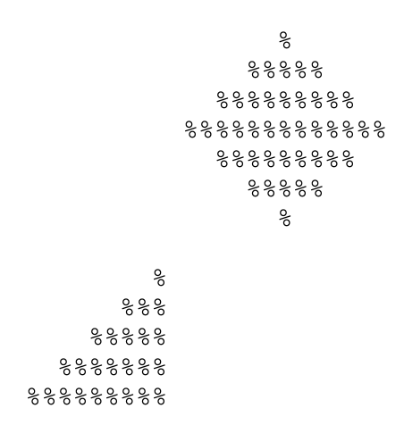

12. Construa um algoritmo para o jogo da velha. Esse jogo consiste em um tabuleiro de

dimensão 3x3 de valores O ou X. Os usuários devem informar a linha e a coluna que desejam preencher. A partir da terceira jogada de cada jogador é necessário verificar se houve algum ganhador. Também é possível que o resultado do jogo seja empate (nenhum jogador preencheu uma coluna, uma linha ou uma diagonal).

13. Faça um programa que calcule e mostre o maior divisor comum de dois números a e b, usando o algoritmo básico de Euclides (temp é uma variável inteira, temporária):

```
    	enquanto b for diferente de 0:
    	  temp = a
    	  a = b
    	  b = temp % b
```

Esse algoritmo deixará o resultado (MDC) em a, no final.

## Processando a Informação: Cap. 4: Estruturas de Repetição (Laços) - Prática 3

[figure not shown]

Este caderno (*Notebook*) é uma parte complementar *online* do livro **[Processando a Informação](https://editora.ufabc.edu.br/matematica-e-ciencias-da-computacao/58-processando-a-informacao): um livro prático de programação independente de linguagem**, que deve ser consultado em caso de dúvidas sobre os temas apresentados.

> Este conteúdo pode ser copiado e alterado livremente, sendo inspirado por este livro.

### Exercícios

Fontes: [ref1](https://docente.ifrn.edu.br/jonathanpereira/disciplinas/algoritmos/estruturas-de-repeticao/view); [ref2](https://www.inf.pucrs.br/~pinho/LaproI/Exercicios/Repeticao/Lista1.htm)

1. Escreva um algoritmo que solicite que o usuário entre com valores inteiros positivos quaisquer. A condição de parada é digitar um número negativo ($<0$). Ao final imprima a quantidade de números digitados, o somatório dos valores digitados, e a média aritmética do somatório.
2. Elabore um algoritmo para fazer cálculo de potenciação. Ou seja, $x^y$. Exemplo: 3^4 = 3 x 3 x 3 x 3. Seu algoritmo deverá solicitar que o usuário entre com o valor da base (x) e do expoente (y) e

apresentar o resultado do cálculo sem utilizar os operadores ** ou ^. Para resolver o problema utilize estrutura de repetição.

3. Escreva um algoritmo que calcule a média da seguinte seqüência numérica a seguir: $1/2 + 1/3 + 1/4 + 1/5 + 1/6 + \cdots + 1/50$. Feito isto, o algoritmo deverá apresentar uma lista contendo todos os números da seqüencia que estão acima da média calculada.
4. Apresente o que será impresso na tela do computador pelos algoritmos a seguir:

a) EXEMPLO

```
início
 declare J, I, X : inteiro
 J ← 100
 X ← 3
 J ← J + 40
 I ← 5 ^ X * 4
 enquanto (X >= 5) então
  J ← J – 15
  X ← X + 1
  I ← I + X - J
 fim enquanto
 escreva J, I, X
fim
```

#### Resposta:

| J | X | I | |:-: |:-: |:-: | | 100 | | | | | 3 | | | 140 | | | | | | 500 |

saída: 140, 500, 3

b)

```
início
 declare J, I, X : inteiro
 J ← 100
 X ← 3
 J ← J + 40
 I ← 5 ^ X * 4
 repita
  J ← J – 15
  X ← X + 1
  I ← I + X - J
 enquanto (X >= 5)
 escreva J, I, X
fim
```

#### Sua Resposta:

| J | X | I | |:-: |:-: |:-: | | | | |

c)

```
início
 declare J, I, X : inteiro
 J ← 100
 X ← 3
 J ← J + 40
 I ← 5 ^ X * 4
 enquanto (X <= 5) faça
  J ← J – 15
  X ← X + 1
  I ← I + X - J
 fim enquanto
 escreva J, I, X
fim
```

#### Sua Resposta:

| J | X | I | |:-: |:-: |:-: | | | | |

d)

```
início
 declare M, N, Y : inteiro
 M ← 10
 Y ← 1
 para N ← 1 até 3 passo 1 faça
  M ← M – 8
  Y ← Y * 3
 fim para
 escreva M, Y, N
fim
```

#### Sua Resposta:

| M | N | Y | |:-: |:-: |:-: | | | | |

e)

```
início
 declare P, Q : inteiro
 declare VALOR : real
 P ← 5
 Q ← P - 8
 VALOR ← 18
 repita
  VALOR ← VALOR + (VALOR * P + Q)
  P ← P + 2
  Q ← Q + 1
 enquanto (Q < 0)
 escreva VALOR
fim
```

#### Sua Resposta:

| P | Q | Valor | |:-: |:-: |:-: | | | | |

f)

```
início
 declare CONT : inteiro
 declare VALOR : real
 declare RESP : caracter
 CONT ← 0
 VALOR ← 0
 RESP ← ‘s’
 enquanto (RESP = ‘s’) faça
  VALOR ← VALOR + 139
  CONT ← CONT + 1
  se (CONT > 3) então
   RESP ← ‘n’
  fim se
 fim enquanto
 escreva VALOR
fim
```

#### Sua Resposta:

| X | X | X | |:-: |:-: |:-: | | | | |

g)

```
início
 declare N : inteiro
 declare SOMA : real
 SOMA ← 0
 para N ← 1 até 5 passo 1 faça
  SOMA ← SOMA + 1 / N
 fim para
 escreva SOMA
fim
```

#### Sua Resposta:

| X | X | X | |:-: |:-: |:-: | | | | |

h)

```
início
 declare N : inteiro
 N ← 0
 enquanto (N < 5) faça
  se (N = 0) então
   escreva “Esse número não existe: 1/0”
  senão
  escreva 1 / N
  fim se
  N ← N + 1
 fim enquanto
fim
```

#### Sua Resposta:

| X | X | X | |:-: |:-: |:-: | | | | |

5. A prefeitura de uma cidade fez uma pesquisa entre seus habitantes, coletando dados sobre o salário e número de filhos. A prefeitura deseja saber:

> a) média do salário da população;

> b) média do número de filhos;

> c) maior salário;

> d) percentual de pessoas com salário até R$10000,00.

O final da leitura de dados se dará com a entrada de um salário negativo. (Use o comando ENQUANTO-FAÇA)

6. Escreva um algoritmo que leia o código de um aluno e suas três notas. Calcule a média ponderada do aluno, considerando que o peso para a maior nota seja 4 e para as duas restantes, 3. Mostre o código do aluno, suas três notas, a média calculada e uma mensagem "APROVADO" se a média for maior ou igual a 5 e "REPROVADO" se a média for menor que 5. Repita a operação até que o código lido seja negativo.
7. Escrever um algoritmo que lê um conjunto não determinado de valores, um de cada vez, e escreve uma tabela com cabeçalho, que deve ser repetido a cada 20 linhas. A tabela conterá o valor lido, seu quadrado, seu cubo e sua raiz quadrada.
8. Escrever um algoritmo que lê um número não determinado de pares de valores m, n, todos inteiros e positivos, um par de cada vez, e calcula e escreve a soma dos n inteiros consecutivos a partir de m inclusive.
9. Escrever um algoritmo que lê um número não determinado de valores para m, todos inteiros e positivos, um de cada vez. Se m for par, verificar quantos divisores possui e escrever esta informação. Se m for ímpar e menor do que 10 calcular e escrever o fatorial de m. Se m for ímpar e maior ou igual a 10 calcular e escrever a soma dos inteiros de 1 até m.
10. Faça um algoritmo que leia uma quantidade não determinada de números positivos. Calcule a quantidade de números pares e ímpares, a média de valores pares e a média geral dos números lidos. O número que encerrará a leitura será zero.
11. Foi realizada uma pesquisa de algumas características físicas da população de um certa região. Foram entrevistadas 500 pessoas e coletados os seguintes dados:

a) sexo: M (masculino) e F (feminino)

b) cor dos olhos: A (azuis), V (verdes) e C (castanhos)

c) cor dos cabelos: L (louros), C (castanhos) e P (pretos)

d) idade

Deseja-se saber:

a maior idade do grupo a quantidade de indivíduos do sexo feminino, cuja idade está entre 18 e 35 anos e que tenham olhos verdes e cabelos louros.

12. Foi feita uma estatística nas 200 principais cidades brasileiras para coletar dados sobre acidentes de trânsito. Foram obtidos os seguintes dados:
- código da cidade
- estado (RS, SC, PR, SP, RJ, ...)
- número de veículos de passeio (em 1992)
- número de acidentes de trânsito com vítimas (em 1992)

Deseja-se saber:

a) qual o maior e o menor índice de acidentes de trânsito e a que cidades pertencem

b) qual a média de veículos nas cidades brasileiras

c) qual a média de acidentes com vítimas entre as cidades do Rio Grande do Sul.

13. Uma loja tem 150 clientes cadastrados e deseja mandar uma correspondência a cada um deles anunciando um bônus especial. Escreva um algoritmo que leia o nome do cliente e o valor das suas compras no ano passado e calcule um bônus de 10% se o valor das compras for menor que 500.000 e de15 %, caso contrário.
14. Faça um algoritmo que mostre os conceitos finais dos alunos de uma classe de 75 alunos, considerando (use o comando CASO):

a) os dados de cada aluno (número de matrícula e nota numérica final) serão fornecidos pelo usuário

b) a tabela de conceitos segue abaixo:

| Nota | Conceito | |:-------------: |:--------: | | de 0,0 a 4,9 | D | | de 5,0 a 6,9 | C | | de 7,0 a 8,9 | B | | de 9,0 a 10,0 | A |

# Processando a Informação: Cap. 5: Vetores

[figure not shown]

Este caderno (*Notebook*) é uma parte complementar *online* do livro **[Processando a Informação](https://editora.ufabc.edu.br/matematica-e-ciencias-da-computacao/58-processando-a-informacao): um livro prático de programação independente de linguagem**, que deve ser consultado em caso de dúvidas sobre os temas apresentados.

> Este conteúdo pode ser copiado e alterado livremente, sendo inspirado por este livro.

## Sumário

- Revisão do capítulo anterior
- Introdução
- Trabalhando com vetores
- Acessando elementos de um vetor
- Formas de percorrer um vetor
- Modularização e vetores
- Eficiência de Algortimos
- Revisão deste capítulo
- Exercícios

## Revisão do capítulo anterior (Estruturas de Repetição - Laços)

- Estruturas de repetição (laços) devem ser utilizadas quando existem instruções que se repentem e podem ser de vários tipos, dependendo da linguagem utilizada, por exemplo:
  - `do-while` (não aceita em Python)
  - `while` (a maioria)
  - `for` (a maioria)
  - `repeat` (R)
- O uso de laços depende da lógica a ser implementada e da linguagem utilizada. Mas, se tiver um número fixo de iterações, geralmente se usa `for`.
- Validação de dados utilizando laços:
  - Incluir um laço para verificar o valor lido.
- Interrupção da execução em laços:
  - Depende da linguagem, algumas possibilidades:
    - `break` - interrompe o laço
    - `continue` - não executa o final do laço
    - `exit` - aborta o laço e o programa!
- Neste capítulo iremos abordar a estrutura de **Vetor**, incluindo os conceitos apresentados nos capítulos anteriores.

## Introdução

- Um **vetor** em programação é formado por um **conjunto de $n$ variáveis de um mesmo tipo** de dado (em geral), sendo $n$ obrigatoriamente maior que zero. Caso contrário, o vetor é considerado vazio.
- Essas variáveis (ou elementos) são identificadas e acessadas por um **nome** e um **índice**.
- Na maioria das linguagens de programação, o **índice** recebe valores de $0$ (**primeiro elemento**) até $n-1$ (**último elemento**).
- As variáveis de um vetor são armazenadas em posições consecutivas de memória.

## Trabalhando com vetores

- Quando um vetor é criado, é instanciada uma variável do tipo vetor (em algumas linguagens de programação, sendo necessário definir um nome, o tipo de dado e o tamanho do vetor).
- Na linguagem C, por exemplo, a definição do tamanho de um vetor ocorre antes de compilar o programa.
  - Ou seja, o programador deverá informar no código a quantidade de memória a ser reservada para o vetor, através de um número inteiro positivo ou constante que o contenha, especificando o número de elementos do mesmo tipo que a memória reservada irá comportar.
  - Neste caso, uma variável não pode ser usada para definir o tamanho do vetor em C.
- Já na linguagem Java, é possível alocar memória em tempo de execução do programa.
  - Por exemplo, é possível criar um vetor para armazenar as notas de uma turma de alunos, onde o número de alunos é uma variável a ser lida durante a execução do programa.
- Em muitas linguagens, como Java e C, o processo de criar um vetor ocorre em dois passos distintos:
  1. Primeiro, cria-se uma variável de referência para o vetor.
  2. Em seguida, reserva-se a memória para um dado número de elementos do mesmo tipo.
- No exemplo da figura abaixo,
  - A criação da variável de referência de um vetor `v` define apenas a posição de memória em hexadecimal `0A`, onde será armazenado o seu primeiro elemento.
    - Neste exemplo, `V[0] = -128` é o primeiro elemento do vetor.
    - A quantidade de `bytes` por elemento vai depender do tipo de dado armazenado. Neste exemplo, cada elemento ocupa um `byte`.
  - O segundo passo da criação de um vetor é reservar (ou alocar) memória para todos os seus elementos (dependendo da linguagem).

  > Essa alocação de memória pode ocorrer em tempo de execução, como ocorre em Python!

[figure not shown]

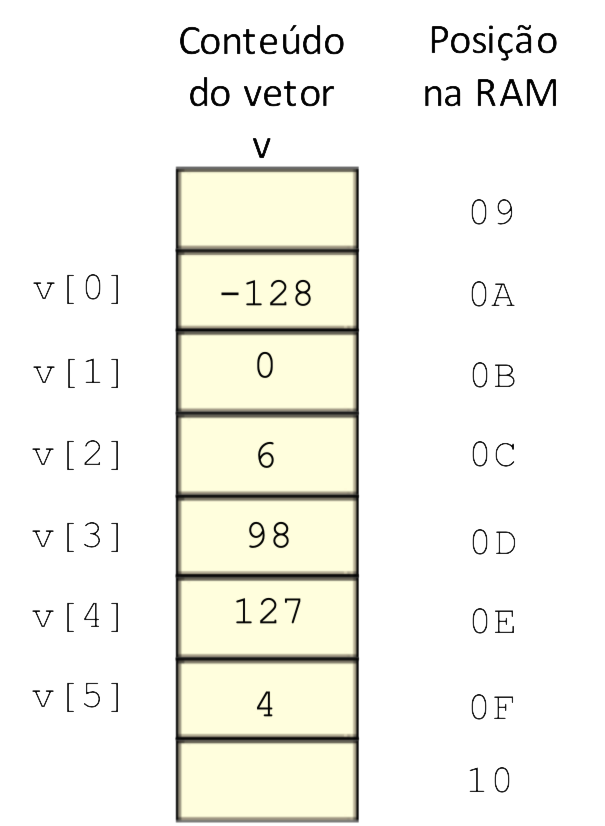

- Note que a variável `v` acima agora se refere a uma posição de memória e não a um elemento de dado.
- Os elementos devem ser acessados através do índice, um por vez.
- Isso pode requerer o uso de laços para leitura, processamento e impressão dos seus elementos, dependendo da linguagem de programação utilizada.
  - O índice do vetor é sempre um número inteiro.

## Exemplo 01 - Ler/Escrever vetor

#### Pseudocódigo

```
Instanciar o vetor v1 de inteiro com tamanho 5 // ou
vetor v2 = vetor de inteiros com 100 elementos // ou ainda
vetor v3 = inteiro(10)
v1 = {4, 1, 10, 2, 3} // atribuindo valores a v1
```

**Exemplo 01:** Ler uma lista com `n` alunos com `RA` e `Nome` e escrever formatando a saída como no exemplo:

```
LISTA DE ALUNOS
Número RA     Nome
1      2134   Maria Campos
2      346    João Silva
```

#### Casos para Teste Moodle+VPL

Para o professor criar uma atividade VPL no Moodle para este Exemplo 01, basta incluir em `Casos para teste`, o seguinte texto (pode incluir mais casos):

```
case=caso1
input=2
2345
9870
Maria Campos
João Silva
output=
LISTA DE ALUNOS
Número RA     Nota
1      2345   Maria Campos
2      9870   João Silva
```

```python
%%writefile cap5ex01.java
import java.util.Scanner;
public class cap5ex01 {
    public static void main(String[] args) {
        // ENTRADA DE DADOS
        System.out.print("Digite o numero de alunos: ");
        Scanner scan = new Scanner(System.in);
        Scanner scan1 = new Scanner(System.in); // ATENÇÃO
        int n = scan.nextInt();        // lê número de elementos
        Integer ra[] = new Integer[n]; // declara e aloca memória
        String nome[] = new String[n]; // declara e aloca memória

        for (int i = 0; i < n; i++) {
            System.out.print("RA: ");
            ra[i] = scan.nextInt();
            System.out.print("Nome: ");
            nome[i] = scan1.nextLine(); // ATENÇÃO
        }
        // PROCESSAMENTO ?
        // SAÍDA DE DADOS
        System.out.println("LISTA DE ALUNOS\nNúmero\t RA\t Nome");
        for (int i = 0; i < n; i++) {
            System.out.println(i + 1 + "\t " + ra[i] + "\t" + nome[i]);
        }
    }
}
```

```python
!javac cap5ex01.java
!java cap5ex01
```

```python
# solução 1
%%writefile cap5ex01.js
function escreva(s) {try {element.append(s)} catch(e) {try {document.write(s)} catch(e) {console.log(s)}}}
const leia = (name) => {return `${name}`}

// ENTRADAS
escreva("Digite o numero de alunos: ")
var n = parseInt(leia(process.argv[2]))    // ATENÇÃO NESTA INSTRUÇÃO!
var ra = [];
var nome = [];
contaLinhas = 3;
for (i=0; i<n; i++) {
    ra[i] = parseInt(leia(process.argv[contaLinhas])) // ATENÇÃO NESTA INSTRUÇÃO!
    nome[i] = leia(process.argv[contaLinhas+1])       // ATENÇÃO NESTA INSTRUÇÃO!
    contaLinhas = contaLinhas + 2
}
// PROCESSAMENTO ?
// SAÍDA DE DADOS
escreva("LISTA DE ALUNOS\nNúmero\t RA\tNome")
for (i=0; i<n; i++) {
    escreva(i + 1 + "\t " + ra[i] + "\t" + nome[i])
}
```

```python
%%shell
node cap5ex01 2 23 ANA 433 "MARIA Julia"
```

Código para executar em antividades no Moodle+VPL. Testar códigos antes de submeter para avaliação, por exemplo, em https://www.jdoodle.com/execute-nodejs-online.

```python
# solução 2: para executar no Moodle+VPL
%%writefile cap5ex01.js
function escreva(s) {try {element.append(s)} catch(e) {try {document.write(s)} catch(e) {console.log(s)}}}
function leia(linhas,i) {return linhas.toString().split('\n')[i]}

process.stdin.once('data', linhas => {
  // ENTRADAS
  escreva("Digite o numero de alunos: ")
  var n = parseInt(leia(linhas,0))    // ATENÇÃO NESTA INSTRUÇÃO!
  var ra = [];
  var nome = [];
  contaLinhas = 1;
  for (i=0; i<n; i++) {
      ra[i] = parseInt(leia(linhas,contaLinhas)) // ATENÇÃO NESTA INSTRUÇÃO!
      nome[i] = leia(linhas,contaLinhas+1)       // ATENÇÃO NESTA INSTRUÇÃO!
      contaLinhas = contaLinhas + 2
  }
  // PROCESSAMENTO ?
  // SAÍDA DE DADOS
  escreva("LISTA DE ALUNOS\nNúmero\t RA\tNome")
  for (i=0; i<n; i++) {
      escreva(i + 1 + "\t " + ra[i] + "\t" + nome[i])
  }
})
```

```python
# NÃO executa NESTE COLAB, SOMENTE NO MOODLE+VPL
%%shell
#node cap5ex01.js 4 5 2
```

```python
%%writefile cap5ex01.c
#include <stdio.h>

int main(void) {

  // ENTRADA DE DADOS
  int max = 100; // considerar sempre um número grande
  int n, ra[max];     // aloca 100 ra's
  char nome[max][40]; // aloca 100 nomes de até 40 caracteres cada

  printf("Digite o numero de alunos: ");
  scanf("%d", &n);
  for (int i = 0; i < n; i++) {
    printf("RA: ");
    scanf("%d", &ra[i]);
    printf("Nome: ");
    scanf("%s", nome[i]); // ATENÇÃO: NÃO ACEITA NOME COM ESPAÇOS e NÃO USA &
  }
  // PROCESSAMENTO ?
  // SAÍDA
  printf("LISTA DE ALUNOS\nNúmero\t RA\t Nome\n");
  for (int i = 0; i < n; i++) {
    printf("%d\t %d\t %s\n", i + 1, ra[i], nome[i]);
  }
  return 0;
}
```

```python
%%shell
gcc -Wall -std=c99 cap5ex01.c -o output2
./output2
```

- As *strings* em C têm um último caracter `'\0'`. Assim, no exemplo a seguir `s1=s2` tem três carateres cada:
  - `char s1[] = "oi";` ou
  - `char s2[] = {'o','i','\0'};`
- Para ler uma *string* com espaços [[ref](https://www.geeksforgeeks.org/gets-is-risky-to-use)]:

```python
%%writefile cap5ex01teste.c
#include <stdio.h>
#include <string.h>

int main() {
   char s[40];
   printf("digite algo:\n");
   fgets(s, 40, stdin);
   printf("saida: \"%s\" tamanho: %ld\n", s, strlen(s));
   s[strlen(s)-1] = '\0'; // substituir \n por \0
   printf("saida: \"%s\" tamanho: %ld\n", s, strlen(s));
   return 0;
}
```

```python
%%shell
gcc -Wall -std=c99 cap5ex01teste.c -o cap5ex01teste
./cap5ex01teste
```

Algumas funções da biblioteca padrão **string.h**:

| função | descrição |
| --- | --- |
| strcopy(s1,s2) | copia s1 em s2 |
| strcat(s1,s2) | copia s2 no final de s1 |
| strlen(s) | tamanho de s |
| strcmp(s1,s2) | 0 se s1=s2; negativo se s1<s2; positivo se s1>s2 |
| strchr(s,ch) | ponteiro para a primeira ocorrência de ch em s |
| strstr(s1,s2) | ponteiro para a primeira ocorrência de s2 em s1 |

Utilizar [pythontutor.com](https://pythontutor.com/) para executar passo-a-passo.

## Formas de Percorrer um Vetor

### Percorrer um vetor com o laço `para`

- Como um vetor, após criado (alocado e com elementos), tem tamanho fixo (sempre com número de elementos `n > 0`), geralmente é indicado usar estruturas de repetição do tipo `para` (`for`), de forma a percorrer todos os elementos do vetor.
  - Isso torna o código genérico para um vetor de qualquer tamanho `n`.
- Além disso, é natural percorrer (ou varrer) o vetor da posição `i = 0` até a posição `i < n`.
  - O índice `i` assume automaticamente os valores `0`, `1`, `2`, até `n-1`, em cada iteração do laço.
  - Em algumas linguagens, como Matlab e R, o índice assume valores entre `1` até `n`.
- No exemplo a seguir em pseudocódigo, um vetor `v` é criado com 6 posições, e o laço `para` inicializa todos os seus elementos com o valor 0.
- A forma natural de percorrer os elementos de um vetor (ou **varrendo** o vetor) é na ordem **raster**, do primeiro até o último elemento.
- A vantagem de se usar a estrutura `para` para varrer um vetor é permitir embutir na própria sintaxe (linha) da instrução:
  - declaração e inicialização do índice,
  - incremento, e
  - condição de saída do laço.

#### Pseudocódigo

```
Instanciar um vetor v de inteiro com 6 elementos (n=6)
para cada índice i, de i=0; até i<n; passo i=i+1 faça
    v[i] = 0
```

### Percorrer um vetor com o laço `enquanto`

- Se o programador preferir, ou o problema a ser resolvido exigir, o vetor pode alternativamente ser percorrido utilizando-se uma estrutura de repetição do tipo `enquanto`:

#### Pseudocódigo

```
n=6
vetor v de inteiros com n elementos
inteiro i=0
enquanto i<n faça {
    v[i] = 0
    i=i+1
}
```

- O código usando a estrutura de repetição `enquanto` produz o mesmo resultado que usando `para`, porém, requer mais instruções:
  - a criação do contador `i`
  - o incremento `i=i+1`.
- Estas duas instruções ficam encapsuladas na própria instrução `para`.

### Outras formas de percorrer um vetor

- Dependendo do problema a ser tratado, existem várias formas de se varrer um vetor usando estruturas de repetição para acessar cada elemento.
- Por exemplo, é possível percorrer o vetor do último elemento para o primeiro (essa varradora é chamada de **anti-raster**):

#### Pseudocódigo: percorrer um vetor usando para na ordem inversa (**anti-raster**).

```
Instanciar um vetor v de inteiro com 6 elementos (n=6)
para cada indice i, de i=n-1; até i<=0; passo i=i-1 faça
    v[i] = 0
```

- Também, é possível percorrer somente alguns elementos do vetor, como para acessar os elementos que estão nos índices pares ou ímpares, diferenciadamente:

#### Pseudocódigo: percorrer um vetor usando `para`, com passo 2.

```
vetor v de inteiro com 6 elementos
n=6
para cada indice i, de i=0; até i<n-1; passo i=i+2 faça {
    v[i] = 0
    v[i+1] = 1
}
```

## Modularização e Vetores

- Como uma boa prática de programação, além de comentar os códigos e organizar com tabulação, como apresentado nos exemplos deste livro,
  - também é recomendável modularizar o código usando métodos, como apresentado no Capítulo 2.
- Todo sistema computadorizado de informação possui três partes bem definidas, agrupadas em
  - módulo(s) de entrada,
  - módulo(s) de processamento e
  - módulo(s) de saída.
- Ao manipular informações armazenadas em vetores, é natural criar também pelo menos três módulos ou métodos:
  - `leiaVetor`,
  - `processaVetor` e
  - `escrevaVetor`,

  satisfazendo essa definição de sistema de informação.

> Para a reutilização de código, os módulos `leiaVetor` e `escrevaVetor` poderão ser amplamente reutilizados para resolver outros problemas de manipulação de vetores.

#### Pseudocódigo: método para ler um vetor de inteiro tamanho n.

```
método leiaVetor(inteiro n): retorna vetor de inteiro v[]
    vetor v de inteiros com n elementos
    para cada índice i, de i=0; até i<n; passo i=i+1 faça
        v[i] = leia("Entre com o elemento " + i + ":");
    retorne v
```

#### Pseudocódigo: método para escrever um vetor de inteiro tamanho n.

```
método escrevaVetor(inteiro v[], inteiro n):
    para cada índice i, de i=0; até i<n; passo i=i+1 faça
        escreva(" " + v[i]);
```

#### Pseudocódigo: aplicação de vetor usando módulos.

```
// Instâncias e Atribuições
inteiro n = leia("Digite o tamanho do vetor:");

// ENTRADA
inteiro v1[] = leiaVetor(n)

// PROCESSAMENTO
// ?

// SAÍDA
escrevaVetor(v2, n)
```

## Exemplo 02 - Aplicação simples 1 usando vetor

Considere um algoritmo para ler a quantidade `n` de alunos de uma turma. Ler uma lista com `n` RA's de alunos. Em seguida, ler também uma lista com `n` notas de alunos. Como saída do algoritmo, escrever a seguinte saída.

```
LISTA DE ALUNOS
Número RA     Nota
1      2134   9
2      346    7
```

Utilizar os métodos `leiaVetor` e `escrevaVetor`, se necessários.

###### Pseudocódigo

```
// ENTRADAS:
// Instâncias e atribuições
real media
real somador = 0
inteiro contador = 0

// Leitura do número de alunos = tamanho do vetor
inteiro n = leia("Digite o número de alunos:")

// Leitura dos vetores RA e notas
inteiro ras[] = leiaVetor(n)
inteiro notas[] = leiaVetor(n)

// PROCESSAMENTO
// ?

// SAÍDAS:
escreva("LISTA DE ALUNOS")
escreva("Número\t RA\t Nota")
para cada indice i, de i=0; até i<n; passo i=i+1 faça
    escreva(i+1, "\t", ras[i], "\t", notas[i])
```

#### Casos para Teste Moodle+VPL

Para o professor criar uma atividade VPL no Moodle para este Exemplo 02, basta incluir em `Casos para teste`, o seguinte texto (pode incluir mais casos):

```
case=caso1
input=2
3456
2345
5
2
output=
LISTA DE ALUNOS
Número	 RA	Nota
1 	 3456 	 5
2 	 2345 	 2
```

```python
%%writefile cap5ex02.java
import java.util.Scanner;

public class cap5ex02 {

    static Scanner scan = new Scanner(System.in);

    public static void main(String[] args) {

        System.out.print("Digite o numero de alunos:");
        int n = scan.nextInt();        // lê número de elementos
        int ras[]; // declara
        int notas[]; // declara

        System.out.println("Entre com " + n + " RAs:");
        ras = leiaVetor(n);
        System.out.println("Entre com " + n + " Notas:");
        notas = leiaVetor(n);

        // PARA VERIFICAÇÃO
        //System.out.println("RA's:");
        //escrevaVetor(ras);
        //System.out.println("Notas:");
        //escrevaVetor(notas);

        System.out.println("LISTA DE ALUNOS\nNúmero\tRA\tNota");
        for (int i = 0; i < n; i++) {
            System.out.println(i + 1 + "\t" + ras[i] + "\t" + notas[i]);
        }
    }

    static int[] leiaVetor(int n) {
        // leitura dos n elmentos do vetor v1
        int[] v = new int[n]; // declara e aloca
        for (int i = 0; i < v.length; i++) {
            //System.out.print("Digite um numero inteiro  " + i + ": ");
            v[i] = scan.nextInt();
        }
        return v;
    }

    static void escrevaVetor(int v[]) {
        for (int i = 0; i < v.length; i++) {
            System.out.println(v[i]);
        }
        System.out.println();
    }
}
```

```python
!javac cap5ex02.java
!java cap5ex02
```

```python
# solução 1
%%writefile cap5ex02.js
function escreva(s) {try {element.append(s)} catch(e) {try {document.write(s)} catch(e) {console.log(s)}}}
const leia = (name) => {return `${name}`}

function leiaVetor(n,contaLinhas) {
    var v = [];
    for (i=0; i<n; i++) {
      v[i] = parseInt(leia(process.argv[contaLinhas])) // ATENÇÃO NESTA INSTRUÇÃO!
      contaLinhas++
    }
    return v
}
// ENTRADAS
escreva("Digite o numero de alunos: ")
var n = parseInt(leia(process.argv[2]))    // ATENÇÃO NESTA INSTRUÇÃO!
var ras = [];
var notas = [];
contaLinhas = 3;
ras = leiaVetor(n,contaLinhas)
contaLinhas += n
notas = leiaVetor(n,contaLinhas)

// PROCESSAMENTO ?
// SAÍDA DE DADOS
escreva("LISTA DE ALUNOS\nNúmero\t RA\tNota")
for (i=0; i<n; i++) {
    escreva(i + 1 + "\t " + ras[i] + "\t" + notas[i])
}
```

```python
%%shell
node cap5ex02 2 2345 3456 5 9
```

Código para executar em antividades no Moodle+VPL. Testar códigos antes de submeter para avaliação, por exemplo, em https://www.jdoodle.com/execute-nodejs-online.

```python
# solução 2: para executar no Moodle+VPL
%%writefile cap5ex02.js
function escreva(s) {try {element.append(s)} catch(e) {try {document.write(s)} catch(e) {console.log(s)}}}
function leia(linhas,i) {return linhas.toString().split('\n')[i]}

function leiaVetor(linhas,n,contaLinhas) {
    var v = [];
    for (i=0; i<n; i++) {
      v[i] = parseInt(leia(linhas,contaLinhas)) // ATENÇÃO NESTA INSTRUÇÃO!
      contaLinhas++
    }
    return v
}

process.stdin.once('data', linhas => {
  // ENTRADAS
  escreva("Digite o numero de alunos: ")
  var n = parseInt(leia(linhas,0))    // ATENÇÃO NESTA INSTRUÇÃO!
  var ras = [];
  var notas = [];
  contaLinhas = 1;
  ras = leiaVetor(linhas,n,contaLinhas)
  contaLinhas += n
  notas = leiaVetor(linhas,n,contaLinhas)

  // PROCESSAMENTO ?
  // SAÍDA DE DADOS
  escreva("LISTA DE ALUNOS\nNúmero\t RA\tNota")
  for (i=0; i<n; i++) {
      escreva(i + 1 + "\t " + ras[i] + "\t" + notas[i])
  }
})
```

```python
# NÃO executa NESTE COLAB, SOMENTE NO MOODLE+VPL
%%shell
#node cap5ex02 2 2345 3456 5 9
```

```python
%%writefile cap5ex02.c
#include <stdio.h>

int main(void) {

  // ENTRADA DE DADOS
  int max = 100; // número máximo de alunos
  int n, ras[max], notas[max];   // variaveis de referência ras e notas

  printf("Digite o numero de alunos: \n");
  scanf("%d", &n);

  printf("RAs: \n");
  for (int i = 0; i < n; i++) {
    printf("RA %d: \n", i + 1);
    scanf("%d", &ras[i]);
  }

  printf("Notas: \n");
  for (int i = 0; i < n; i++) {
    printf("Nota %d: \n", i + 1);
    scanf("%d", &notas[i]);
  }

  // PROCESSAMENTO ?
  // SAÍDA
  printf("LISTA DE ALUNOS\nNúmero\t RA\t Nota\n");
  for (int i = 0; i < n; i++) {
    printf("%d\t %d\t %d\n", i + 1, ras[i], notas[i]);
  }
  return 0;
}
```

```python
%%shell
gcc -Wall -std=c99 cap5ex02.c -o output2
./output2
```

Existem várias formas de usar vetor em métodos:

- como argumento:
  - `void metodo (int *v, int n) {...}`
  - `void metodo (int v[], int n) {...}`
  - `void metodo (int v[max], int n) {...}`
- como retorno:
  - `int * metodo (int n) {...}` - alocar vetor dentro do método, alocação dinâmica de memória, com `malloc` ou `calloc`.
  - não esquecer de liberar a memórica com `free`.

```python
%%writefile cap5ex02teste1.c
#include <stdio.h>

#define MAX_ALUNOS 20 // número máximo de alunos

void leiaVetor(int *v, int n) {
  for (int i = 0; i < n; i++)
    scanf("%d", &v[i]);
}

int main(void) {

  // ENTRADA DE DADOS
  int n, ras[MAX_ALUNOS], notas[MAX_ALUNOS];   // variaveis de referência ras e notas

  printf("Digite o numero de alunos: \n");
  scanf("%d", &n);

  printf("RAs: \n");
  leiaVetor(ras, n);

  printf("Notas: \n");
  leiaVetor(notas, n);

  // PROCESSAMENTO ?
  // SAÍDA
  printf("LISTA DE ALUNOS\nNúmero\t RA\t Nota\n");
  for (int i = 0; i < n; i++)
    printf("%d\t %d\t %d\n", i + 1, ras[i], notas[i]);

  return 0;
}
```

```python
%%shell
gcc -Wall -std=c99 cap5ex02teste1.c -o output2
./output2
```

```python
%%writefile cap5ex02teste2.c
#include <stdio.h>
#include <stdlib.h>  // malloc e free

int * leiaVetor(int n) {
  int *v= malloc(sizeof(n));  // ALOCAÇÃO DINÂMICA
  for (int i = 0; i < n; i++) {
    scanf("%d", &v[i]);
  }
  return v;
}

int main(void) {

  // ENTRADA DE DADOS
  int n, *ras, *notas;   // variaveis de referência ras e notas

  printf("Digite o numero de alunos: ");
  scanf("%d", &n);

  printf("RAs: ");
  ras = leiaVetor(n);

  printf("Notas: ");
  notas = leiaVetor(n);

  // PROCESSAMENTO ?
  // SAÍDA
  printf("LISTA DE ALUNOS\nNúmero\t RA\t Nota\n");
  for (int i = 0; i < n; i++) {
      printf("%d\t %d\t %d\n",i+1, ras[i],notas[i]);
  }
  free(ras);   // LIBERAR MEMÓRIA ALOCADA COM malloc
  free(notas);
  return 0;
}
```

```python
%%shell
gcc -Wall -std=c99 cap5ex02teste2.c -o output2
./output2
```

Utilizar [pythontutor.com](https://pythontutor.com/) para executar passo-a-passo.

## Exemplo 03 - Aplicação simples 2 usando vetor

Considere um algoritmo para ler a quantidade `n` de alunos de uma turma. Ler também uma lista com `n` notas de alunos. Como saída do algoritmo, escrever a média da turma e quantos alunos ficaram acima da média.

###### Pseudocódigo

```
// ENTRADAS:
// Instâncias e atribuições
real media, somador = 0
inteiro contador = 0

// Leitura do número de alunos = tamanho do vetor
inteiro n = leia("Digite o número de alunos:")

// Leitura dos vetores de RAs e notas
inteiro ras[] = leiaVetor(n)
real notas[] = leiaVetor(n)

// PROCESSAMENTO: soma, média e contador
para cada índice i, de i=0; até i<n; passo i=i+1 faça
    somador = somador + notas[i] // Soma das notas
media = somador / n   // Cálculo da média

para cada índice i, de i=0; até i<n; passo i=i+1 faça
    se (notas[i] >= media) // Conta alunos com nota acima ou igual à média
        contador = contador + 1

// SAÍDAS:
escreva("Média da turma = " + media) // Saída da média
escreva("Alunos acima ou igual à média: " + contador)
escreva("LISTA DE ALUNOS ACIMA OU IGUAL À MÉDIA")
escreva("RA\t Nota")
para cada índice i, de i=0; até i<n; passo i=i+1 faça
    se (nota[i] >= media)
        escreva(ras[i], "\t", notas[i]) // Saída dos alunos acima ou igual à média
```

#### Casos para Teste Moodle+VPL

Para o professor criar uma atividade VPL no Moodle para este Exemplo 03, basta incluir em `Casos para teste`, o seguinte texto (pode incluir mais casos):

```
case=caso1
input=2
233245
234534
9
4
output=
Média da turma = 6.5
Número de alunos acima da média = 1
LISTA DE ALUNOS ACIMA DA MÉDIA
RA      Nota
233245  9
```

```python
%%writefile cap5ex03.java

import java.util.Scanner;

public class cap5ex03 {

    static Scanner scan = new Scanner(System.in);

    public static void main(String[] args) {

        // ENTRADA DE DADOS
        System.out.print("Digite o numero de alunos:");
        int n = scan.nextInt();        // lê número de elementos
        int ras[];   // declara
        int notas[]; // declara
        int somador = 0, contador = 0;
        float media;

        System.out.println("Entre com " + n + " RAs:");
        ras = leiaVetor(n);
        System.out.println("Entre com " + n + " Notas:");
        notas = leiaVetor(n);


        // PROCESSAMENTO: soma, média e contador
        for (int i = 0; i < notas.length; i++) {
            somador = somador + notas[i];   // soma
        }
        media = (float) somador / n;            // média

        for (int i = 0; i < notas.length; i++) {
            if (notas[i] >= media) {        // conta alunos>=media
                contador = contador + 1;
            }
        }
        // SAÍDA:
        System.out.println("Média da turma = " + media);
        System.out.println("Número de alunos acima da média = " + contador);
        System.out.println("LISTA DE ALUNOS ACIMA DA MÉDIA\nRA\tNota");
        for (int i = 0; i < n; i++) {
            if (notas[i] >= media) {        // conta alunos>=media
              System.out.println(ras[i] + "\t" + notas[i]);
            }
        }
    }

    static int[] leiaVetor(int n) {
        // leitura dos n elementos do vetor v1
        int[] v = new int[n]; // declara e aloca
        for (int i = 0; i < v.length; i++) {
            //System.out.print("Digite um numero inteiro  " + i + ": ");
            v[i] = scan.nextInt();
        }
        return v;
    }
}
```

```python
!javac cap5ex03.java
!java cap5ex03
```

```python
# solução 1
%%writefile cap5ex03.js
function escreva(s) {try {element.append(s)} catch(e) {try {document.write(s)} catch(e) {console.log(s)}}}
const leia = (name) => {return `${name}`}

function leiaVetor(n,contaLinhas) {
    var v = [];
    for (i=0; i<n; i++) {
      v[i] = parseInt(leia(process.argv[contaLinhas])) // ATENÇÃO NESTA INSTRUÇÃO!
      contaLinhas++
    }
    return v
}

// ENTRADAS
escreva("Digite o numero de alunos: ")
var n = parseInt(leia(process.argv[2]))    // ATENÇÃO NESTA INSTRUÇÃO!
var ras = [];
var notas = [];
contaLinhas = 3;
somador = 0
contador = 0

ras = leiaVetor(n,contaLinhas)
contaLinhas += n
notas = leiaVetor(n,contaLinhas)

// PROCESSAMENTO: soma, média e contador
for (i = 0; i < n; i++) {
    somador = somador + notas[i];   // soma
}
media = somador / n; // média

for (i = 0; i < n; i++) {
    if (notas[i] >= media) {        // conta alunos>=media
        contador = contador + 1;
    }
}

// SAÍDA DE DADOS
escreva("Média da turma = " + media);
escreva("Número de alunos acima da média = " + contador);
escreva("LISTA DE ALUNOS ACIMA DA MÉDIA\nRA\tNota");
for (i=0; i<n; i++) {
  if (notas[i] >= media) {
    escreva(ras[i] + "\t" + notas[i])
  }
}
```

```python
%%shell
node cap5ex03 2 2345 3456 6 9
```

Código para executar em antividades no Moodle+VPL. Testar códigos antes de submeter para avaliação, por exemplo, em https://www.jdoodle.com/execute-nodejs-online.

```python
# solução 2: para executar no Moodle+VPL
%%writefile cap5ex03.js
function escreva(s) {try {element.append(s)} catch(e) {try {document.write(s)} catch(e) {console.log(s)}}}
function leia(linhas,i) {return linhas.toString().split('\n')[i]}

function leiaVetor(linhas,n,contaLinhas) {
    var v = [];
    for (i=0; i<n; i++) {
      v[i] = parseInt(leia(linhas,contaLinhas)) // ATENÇÃO NESTA INSTRUÇÃO!
      contaLinhas++
    }
    return v
}

process.stdin.once('data', linhas => {
  // ENTRADAS
  escreva("Digite o numero de alunos: ")
  var n = parseInt(leia(linhas,0))    // ATENÇÃO NESTA INSTRUÇÃO!
  var ras = [];
  var notas = [];
  contaLinhas = 1;
  somador = 0
  contador = 0

  ras = leiaVetor(linhas,n,contaLinhas)
  contaLinhas += n
  notas = leiaVetor(linhas,n,contaLinhas)

  // PROCESSAMENTO: soma, média e contador
  for (i = 0; i < n; i++) {
      somador = somador + notas[i];   // soma
  }
  media = somador / n; // média

  for (i = 0; i < n; i++) {
      if (notas[i] >= media) {        // conta alunos>=media
          contador = contador + 1;
      }
  }

  // SAÍDA DE DADOS
  escreva("Média da turma = " + media);
  escreva("Número de alunos acima da média = " + contador);
  escreva("LISTA DE ALUNOS ACIMA DA MÉDIA\nRA\tNota");
  for (i=0; i<n; i++) {
    if (notas[i] >= media) {
      escreva(ras[i] + "\t" + notas[i])
    }
  }
})
```

```python
# NÃO executa NESTE COLAB, SOMENTE NO MOODLE+VPL
%%shell
#node cap5ex03 2 2345 3456 5 9
```

```python
# solução 1
%%writefile cap3ex01.js
function escreva(s) {try {element.append(s)} catch(e) {try {document.write(s)} catch(e) {console.log(s)}}}
const leia = (name) => {return `${name}`}

// ENTRADAS
escreva("Digite o numero de alunos: ")
var n = parseInt(leia(process.argv[2]))    // ATENÇÃO NESTA INSTRUÇÃO!
var ra = [];
var nome = [];
contaLinhas = 3;
for (i=0; i<n; i++) {
    ra[i] = parseInt(leia(process.argv[contaLinhas])) // ATENÇÃO NESTA INSTRUÇÃO!
    nome[i] = leia(process.argv[contaLinhas+1])       // ATENÇÃO NESTA INSTRUÇÃO!
    contaLinhas = contaLinhas + 2
}
// PROCESSAMENTO ?
// SAÍDA DE DADOS
escreva("LISTA DE ALUNOS\nNúmero\t RA\tNome")
for (i=0; i<n; i++) {
    escreva(i + 1 + "\t " + ra[i] + "\t" + nome[i])
}
```

```python
%%shell
node cap3ex01 2 23 ANA 433 "MARIA Julia"
```

Código para executar em antividades no Moodle+VPL. Testar códigos antes de submeter para avaliação, por exemplo, em https://www.jdoodle.com/execute-nodejs-online.

```python
# solução 2: para executar no Moodle+VPL
%%writefile cap5ex01.js
function escreva(s) {try {element.append(s)} catch(e) {try {document.write(s)} catch(e) {console.log(s)}}}
function leia(linhas,i) {return linhas.toString().split('\n')[i]}

process.stdin.once('data', linhas => {
  // ENTRADAS
  escreva("Digite o numero de alunos: ")
  var n = parseInt(leia(linhas,0))    // ATENÇÃO NESTA INSTRUÇÃO!
  var ra = [];
  var nome = [];
  contaLinhas = 1;
  for (i=0; i<n; i++) {
      ra[i] = parseInt(leia(linhas,contaLinhas)) // ATENÇÃO NESTA INSTRUÇÃO!
      nome[i] = leia(linhas,contaLinhas+1)       // ATENÇÃO NESTA INSTRUÇÃO!
      contaLinhas = contaLinhas + 2
  }
  // PROCESSAMENTO ?
  // SAÍDA DE DADOS
  escreva("LISTA DE ALUNOS\nNúmero\t RA\tNome")
  for (i=0; i<n; i++) {
      escreva(i + 1 + "\t " + ra[i] + "\t" + nome[i])
  }
})
```

```python
# NÃO executa NESTE COLAB, SOMENTE NO MOODLE+VPL
%%shell
#node cap5ex01.js 4 5 2
```

```python
%%writefile cap5ex03.c
#include <stdio.h>
#include <stdlib.h>

int * leiaVetor(int n) {
  int *v= malloc(sizeof(n));
  for (int i = 0; i < n; i++) {
    scanf("%d", &v[i]);
  }
  return v;
}

int main(void) {

  // ENTRADA DE DADOS
  int n, *ras, *notas;   // variaveis de referência ras e notas
  float media,somador = 0.0;
  int contador = 0;

  printf("Digite o numero de alunos: ");
  scanf("%d", &n);

  printf("RAs: ");
  ras = leiaVetor(n);

  printf("Notas: ");
  notas = leiaVetor(n);

  // PROCESSAMENTO: soma, média e contador
  for (int i = 0; i < n; i++) {
      somador = somador + notas[i];   // soma
  }
  media = (float) somador / n;            // média

  for (int i = 0; i < n; i++) {
      if (notas[i] >= media) {        // conta alunos>=media
          contador = contador + 1;
      }
  }
  // SAÍDA DE DADOS
  printf("Média da turma = %.1f\n",media);
  printf("Número de alunos acima da média = %d\n",contador);
  printf("LISTA DE ALUNOS ACIMA DA MÉDIA\nRA\t Nota\n");
  for (int i = 0; i < n; i++) {
    if (notas[i] >= media) {        // conta alunos>=media
      printf("%d\t %d\n",ras[i],notas[i]);
    }
  }
  free(ras);  // liberar memória alocado com malloc
  free(notas);
  return 0;
}
```

```python
%%shell
gcc -Wall -std=c99 cap5ex03.c -o output2
./output2
```

Utilizar [pythontutor.com](https://pythontutor.com/) para executar passo-a-passo.